# Latihan Aug 2026 — Panduan Final Tugas 1–6

2026-10-05

Kode di halaman ini memakai data `Caravan` dari paket `ISLR2` (`data("Caravan")`). File Excel di bawah adalah dataset versi soal untuk peserta.

Caravan Insurance Dataset · peserta (Excel) · 1.8 MB

# Masalah bisnis dan alur pengerjaan

Perusahaan ingin memahami profil pembeli polis caravan, menemukan segmen serupa, dan memprioritaskan kontak pemasaran yang memiliki biaya. Kelas pembeli jarang, sehingga kualitas daftar kontak pada kapasitas 20% lebih relevan daripada accuracy saja. Panduan ini mengikuti enam tugas dan seluruh subsoal (total 100 poin). Tugas 1–3 bersifat audit/eksplorasi; Tugas 4–5 melakukan validasi prediksi; Tugas 6 menyusun keputusan manajemen dari bukti tersebut.

# Ruang lingkup dan nama variabel

Analisis hanya memakai **14 prediktor yang ditetapkan dan satu target Purchase**. Kolom lain dari Caravan tidak masuk audit maupun analisis berikutnya. Nama Inggris memakai underscore agar mudah ditulis di R tanpa backtick. `Purchase` tetap dipakai karena sudah berbahasa Inggris.

| Kode asli | Nama kolom Inggris | Makna ringkas |
| --- | --- | --- |
| `MOSTYPE` | `customer_subtype` | Customer subtype |
| `MAANTHUI` | `number_of_houses` | Number of houses |
| `MGEMOMV` | `average_household_size` | Average household size |
| `MGEMLEEF` | `average_age_category` | Average age category |
| `MOPLHOOG` | `high_level_education` | High level education |
| `MHKOOP` | `home_owners` | Home owners |
| `MHHUUR` | `rented_house` | Rented house |
| `MAUT1` | `one_car_households` | One-car households |
| `MAUT2` | `two_car_households` | Two-car households |
| `MINKGEM` | `average_income` | Average income |
| `MKOOPKLA` | `purchasing_power_class` | Purchasing power class |
| `PPERSAUT` | `contribution_car_policies` | Contribution car policies |
| `PBRAND` | `contribution_fire_policies` | Contribution fire policies |
| `APERSAUT` | `number_of_car_policies` | Number of car policies |
| `Purchase` | `Purchase` | Membeli polis caravan: No/Yes |

Nama kolom menjelaskan makna variabel, **tidak mengubah skala data**. `average_income` dan kontribusi polis masih berupa kode kelas, bukan nominal rupiah; `average_age_category` bukan usia tahun aktual. Banyak karakteristik rumah tangga merupakan profil wilayah, bukan kepastian kondisi individu.

```r
library(ISLR2)
library(psych)
library(dplyr)
```

```r
library(ggplot2)
library(factoextra) # PCA dan grafik clustering
library(cluster)    # kualitas cluster final
library(rpart)    # decision tree dan pruning
library(rpart.plot) # gambar dan aturan tree
library(caret)      # alternatif confusion matrix
library(pROC)       # alternatif ROC dan AUC
# Tampilan grafik konsisten; grafik utama tetap dengan fungsi sederhana
theme_set(theme_minimal(base_size = 12))
data("Caravan")

# Pilih hanya 14 prediktor dan satu target
# Rename langsung agar semua kode berikutnya memakai nama Inggris
dat = Caravan %>%
  select(
    MOSTYPE, MAANTHUI, MGEMOMV, MGEMLEEF, MOPLHOOG,
    MHKOOP, MHHUUR, MAUT1, MAUT2, MINKGEM,
    MKOOPKLA, PPERSAUT, PBRAND, APERSAUT, Purchase
  ) %>%
  rename(
    customer_subtype = MOSTYPE,
    number_of_houses = MAANTHUI,
    average_household_size = MGEMOMV,
    average_age_category = MGEMLEEF,
    high_level_education = MOPLHOOG,
    home_owners = MHKOOP,
    rented_house = MHHUUR,
    one_car_households = MAUT1,
    two_car_households = MAUT2,
    average_income = MINKGEM,
    purchasing_power_class = MKOOPKLA,
    contribution_car_policies = PPERSAUT,
    contribution_fire_policies = PBRAND,
    number_of_car_policies = APERSAUT
  )

dat_asli = dat  # salinan 15 kolom terpilih sebelum cleaning
names(dat)
```

```
##  [1] "customer_subtype"           "number_of_houses"
##  [3] "average_household_size"     "average_age_category"
##  [5] "high_level_education"       "home_owners"
##  [7] "rented_house"               "one_car_households"
##  [9] "two_car_households"         "average_income"
## [11] "purchasing_power_class"     "contribution_car_policies"
## [13] "contribution_fire_policies" "number_of_car_policies"
## [15] "Purchase"
```

```r
dim(dat)
```

```
## [1] 5822   15
```

```r
head(dat)
```

```
##   customer_subtype number_of_houses average_household_size average_age_category
## 1               33                1                      3                    2
## 2               37                1                      2                    2
## 3               37                1                      2                    2
## 4                9                1                      3                    3
## 5               40                1                      4                    2
## 6               23                1                      2                    1
##   high_level_education home_owners rented_house one_car_households
## 1                    1           8            1                  8
## 2                    0           7            2                  7
## 3                    0           2            7                  7
## 4                    3           4            5                  9
## 5                    5           5            4                  6
## 6                    0           0            9                  5
##   two_car_households average_income purchasing_power_class
```

[output cut: 20 more lines]

> **Cara membaca:** audit, solusi yang dipilih, EDA, PCA, K-means, regresi logistik, decision tree, dan ringkasan manajemen dijalankan berurutan saat Knit. Seluruh angka pada narasi mengikuti output kode. Sembilan alternatif grafik Tugas 2 serta alternatif confusion matrix, ROC-AUC, threshold, dan grafik ROC juga dijalankan tepat di bagian terkait sebagai bahan belajar. Hanya contoh cleaning/model yang tidak dipilih serta pemuatan dataset latihan lain memakai `eval=FALSE`.

> Jika paket belum tersedia, jalankan `install.packages(c("ISLR2", "dplyr", "ggplot2", "psych", "factoextra", "cluster", "rpart", "rpart.plot", "caret", "pROC", "rmarkdown", "knitr"))` sekali di Console, lalu Knit.

> Pakai fungsi dasar R ketika lebih ringkas (`na.omit()`, `table()`, `str()`). Pakai dplyr untuk filter, select, mutate, dan ringkasan berkelompok. `%>%` berarti “kemudian”. PCA dan grafik clustering memakai factoextra.

> **Alur data:** pilih 14 prediktor + Purchase → rename ke Inggris → `dat_asli` → audit → `dat_clean` → perbaiki tipe → `dat` untuk EDA. Tugas 3 membuat `dat_pca` dan `segmen_cluster`; Tugas 4 membuat `train`/`test` dari `dat`, bukan dari cluster. `Purchase`, ID, dan hasil cluster tidak masuk input PCA/K-means. ID dan cluster tidak masuk prediktor GLM/tree. Tugas 5 memakai ulang split Tugas 4; Tugas 6 merangkum hasil yang sudah dihitung.

# Tugas 1 (15 poin): Data Audit, Cleaning, dan Persiapan

| Subnomor | Penjelasan | Solusi | Fungsi Utama |
| --- | --- | --- | --- |
| (a), 7 poin | Anda diminta memeriksa lima aspek kualitas data serta masalah, bukti, akibat, dan tindakan. | 1. Hitung missing dan baris identik. 2. Cek nilai unik/dominan, tipe, dan Purchase. 3. Jelaskan dampak. 4. Jalankan solusi yang sesuai; median/modus/penghapusan hanya alternatif jika benar-benar diper… | `is.na()`, `duplicated()`, `sapply()`, `table()`, `str()`, `filter()`, `mutate()` |
| (b), 4 poin | Anda diminta memutuskan apakah observasi identik langsung dihapus. | 1. Bedakan kesamaan profil dan kesalahan pencatatan. 2. Pertahankan baris tanpa bukti ID/sumber. 3. Jika pencatatan ganda terkonfirmasi, penghapusan merupakan alternatif. | `duplicated()`, `unique()` (alternatif) |
| (c), 4 poin | Anda diminta menjelaskan persiapan PCA/K-means, GLM, dan tree. | 1. Tentukan input/metode dan tipe. 2. PCA perlu scaling; GLM/tree perlu split. 3. Semua seleksi prediktif pada training. 4. Tree tidak perlu scaling; siapkan penanganan imbalance dan pruning CV. | `select()`, `factor()`, `prcomp()`, `slice_sample()`, `glm()`, `rpart()` |

## (a) Audit kualitas data (7 poin)

Sebelum melakukan analisis, periksa apakah terdapat masalah yang dapat memengaruhi hasil, sekurang-kurangnya dari aspek berikut:

- missing value;
- duplikasi;
- variabel yang tidak memiliki atau hampir tidak memiliki variasi;
- tipe/skala data;
- ketidakseimbangan kelas Purchase.

Untuk setiap masalah yang ditemukan, jelaskan:

1. apa masalahnya;
2. bagaimana Anda mengetahuinya;
3. konsekuensi jika masalah tersebut diabaikan;
4. tindakan yang Anda rekomendasikan.

### Missing Value

#### Deteksi

```r
# Total missing value
sum(is.na(dat))
```

```
## [1] 0
```

```r
# Missing value per variabel
colSums(is.na(dat))
```

```
##           customer_subtype           number_of_houses
##                          0                          0
##     average_household_size       average_age_category
##                          0                          0
##       high_level_education                home_owners
##                          0                          0
##               rented_house         one_car_households
##                          0                          0
##         two_car_households             average_income
##                          0                          0
##     purchasing_power_class  contribution_car_policies
##                          0                          0
## contribution_fire_policies     number_of_car_policies
##                          0                          0
##                   Purchase
##                          0
```

**Hasil audit:** terdapat 0 nilai hilang.

- **Masalah:** missing value adalah nilai yang tidak tersedia. Jika seluruh hasil pemeriksaan bernilai 0, tidak ditemukan missing value.
- **Bagaimana Anda mengetahuinya:** `is.na()` mendeteksi nilai hilang, kemudian `sum()` dan `colSums()` menghitung jumlahnya.
- **Konsekuensi jika diabaikan:** beberapa fungsi analisis dapat menghasilkan `NA`, gagal dijalankan, atau membuang baris secara otomatis sehingga jumlah data berkurang.
- **Tindakan yang direkomendasikan:** jika tidak ada missing value, tidak perlu penanganan. Jika ada, periksa penyebab dan jumlahnya. Untuk prediktor numerik, pertimbangkan imputasi median; untuk kategorik, modus. Pada pemodelan, nilai imputasi dihitung dari training dan diterapkan pada test. Penghapusan baris lebih mudah, tetapi perlu mempertimbangkan kehilangan data dan risiko bias.

#### Strategi dan solusi

**Solusi dipilih — Tidak mengubah data karena Caravan tidak memiliki missing.**

```r
# Bila memakai dataset lain dengan missing, tinjau ulang solusi terlebih dahulu
stopifnot(sum(is.na(dat)) == 0)
dat_clean = dat
```

**Alternatif — Menghapus baris yang memiliki missing.**

```r
# Simpan hasilnya sebagai data baru
dat_lengkap = na.omit(dat)

# Periksa jumlah baris yang hilang
nrow(dat) - nrow(dat_lengkap)
```

Gunakan jika kehilangan baris masih dapat diterima dan mekanisme missing tidak menimbulkan bias yang berarti. Menghapus baris bukan selalu pilihan terbaik hanya karena missing sedikit.

**Alternatif — Mengisi missing pada prediktor numerik dengan median.**

```r
# Contoh satu prediktor; jangan mengisi target Purchase
dat_median = dat %>%
  mutate(average_income = ifelse(is.na(average_income),
                         median(average_income, na.rm = TRUE), average_income))
```

`ifelse()` memilih nilai pengganti saat kondisi TRUE, dan mempertahankan nilai asli saat FALSE.

**Alternatif — Mengisi missing pada prediktor kategorik dengan modus.** Modus adalah kategori yang paling sering muncul.

```r
# Cari kategori customer_subtype yang paling sering muncul
frekuensi = table(dat_asli$customer_subtype)
modus = as.numeric(names(frekuensi)[which.max(frekuensi)])

# Pakai data asli: customer_subtype masih kode numerik
dat_modus = dat_asli %>%
  mutate(customer_subtype = factor(ifelse(is.na(customer_subtype), modus, customer_subtype)))
```

Jika beberapa kategori mempunyai frekuensi tertinggi yang sama, contoh ini mengambil kategori pertama dari tabel. Contoh modus memakai `customer_subtype` numerik dari data asli Caravan; `as.numeric()` mengubah nama kode pada tabel kembali menjadi angka. Untuk kolom kategori teks, nama modus tetap berupa teks.

Median/modus memerlukan nilai yang teramati; kolom yang seluruhnya missing harus ditangani terpisah. Contoh alternatif untuk prediksi, gunakan pola berikut **setelah training dan test tersedia**:

```r
# Median hanya dihitung dari training
nilai_median = median(train$average_income, na.rm = TRUE)
train = train %>%
  mutate(average_income = ifelse(is.na(average_income), nilai_median, average_income))
test = test %>%
  mutate(average_income = ifelse(is.na(average_income), nilai_median, average_income))
```

**Keputusan untuk Caravan:** hasil audit 0, pertahankan data tanpa imputasi atau penghapusan baris. Target `Purchase` yang hilang jangan diisi dengan modus; telusuri labelnya atau keluarkan dari fitting model supervised.

### Duplikasi

#### Deteksi

```r
# Jumlah baris tambahan yang identik
sum(duplicated(dat))
```

```
## [1] 1307
```

**Hasil audit:** terdapat 1307 baris tambahan yang identik dengan baris sebelumnya. Ini bukan jumlah seluruh baris yang termasuk kelompok duplikat. Pemeriksaan sekarang hanya pada 14 prediktor terpilih dan Purchase: profil yang sama pada kolom ini belum tentu sama pada kolom Caravan yang tidak dipakai, dan belum membuktikan pelanggan yang sama.

- **Masalah:** terdapat duplikasi apabila hasil pemeriksaan lebih dari 0. Artinya, ada baris yang seluruh nilainya sama dengan baris sebelumnya.
- **Bagaimana Anda mengetahuinya:** `duplicated()` menandai baris identik, lalu `sum()` menghitung jumlah baris tambahan tersebut.
- **Konsekuensi jika diabaikan:** jika berasal dari kesalahan pencatatan, pelanggan yang sama dapat dihitung berulang sehingga distribusi dan hasil analisis menjadi bias.
- **Tindakan yang direkomendasikan:** jangan langsung menghapus baris identik. Pada data Caravan, pelanggan berbeda dapat mempunyai profil yang sama. Periksa ID pelanggan atau sumber pencatatan terlebih dahulu. Jika tidak ada bukti pencatatan ganda, pertahankan baris tersebut.

#### Strategi dan solusi

**Langkah pemeriksaan — Melihat contoh baris identik.**

```r
# Lihat contoh baris tambahan yang identik
dat %>% filter(duplicated(.)) %>% head()
```

```
##     customer_subtype number_of_houses average_household_size
## 226               37                1                      2
## 291               34                2                      3
## 308               35                1                      4
## 349               35                1                      4
## 382               33                1                      4
## 384               33                1                      2
##     average_age_category high_level_education home_owners rented_house
## 226                    3                    2           6            3
## 291                    2                    0           7            2
## 308                    3                    0           0            9
## 349                    3                    0           0            9
## 382                    2                    1           1            8
## 384                    3                    0           9            0
##     one_car_households two_car_households average_income purchasing_power_class
```

[output cut: 20 more lines]

**Solusi dipilih — Mempertahankan baris ketika belum terbukti salah.**

Ini keputusan yang direkomendasikan pada Caravan.

```r
# Buat salinan tanpa menghapus baris
dat_clean = dat
```

**Alternatif — Menghapus baris identik hanya jika terbukti pencatatan ganda.**

```r
# Pertahankan kemunculan pertama dari setiap baris identik
dat_tanpa_duplikat = unique(dat)
```

Jika ada ID pelanggan, pemeriksaan harus mengacu pada ID dan konteks pengamatan. Satu pelanggan dengan beberapa transaksi belum tentu duplikasi yang salah. Jangan memilih opsi penghapusan semata-mata karena `duplicated()` menghasilkan TRUE.

### Variabel Tidak Variatif

#### Deteksi

```r
# Jumlah nilai unik, tanpa menghitung missing
unik = sapply(dat, n_distinct, na.rm = TRUE)

# Proporsi nilai paling dominan; kolom seluruhnya NA diberi NA
dominan = sapply(dat, function(x) {
  if (all(is.na(x))) return(NA_real_)
  max(prop.table(table(x)))
})

# Jadikan tabel agar mudah difilter dengan dplyr
audit_var = data.frame(variabel = names(dat), unik, dominan,
                       row.names = NULL)

# Variabel konstan
audit_var %>% filter(unik == 1)
```

```
## [1] variabel unik     dominan
## <0 rows> (or 0-length row.names)
```

```r
# Variabel hampir tidak variatif
audit_var %>% filter(dominan >= 0.95, unik > 1)
```

```
## [1] variabel unik     dominan
## <0 rows> (or 0-length row.names)
```

- **Masalah:** variabel konstan hanya mempunyai satu nilai. Variabel hampir tidak variatif mempunyai satu nilai yang sangat dominan; di sini digunakan batas sederhana ≥95%.
- **Bagaimana Anda mengetahuinya:** jumlah nilai unik menunjukkan variabel konstan, sedangkan proporsi nilai paling dominan menunjukkan variabel yang hampir tidak variatif.
- **Konsekuensi jika diabaikan:** variabel konstan tidak membantu membedakan pelanggan dan dapat menyebabkan standardisasi PCA gagal karena simpangan bakunya nol. Variabel yang sangat jarang berubah dapat menghasilkan pola yang kurang stabil.
- **Tindakan yang direkomendasikan:** keluarkan variabel konstan dari analisis. Pertimbangkan mengeluarkan variabel hampir tidak variatif dari PCA/clustering. Untuk prediksi, periksa relevansinya terlebih dahulu karena karakteristik yang jarang tetap bisa berguna. Batas 95% merupakan aturan audit sederhana, bukan definisi universal.

#### Strategi dan solusi

**Solusi dipilih — Mengeluarkan variabel konstan.** Kolom yang seluruhnya missing juga tidak memberi informasi teramati.

```r
# Ambil nama kolom yang memiliki paling banyak satu nilai teramati
konstan = audit_var %>% filter(unik <= 1) %>% pull(variabel)

# Buat data baru; data asli tetap tersedia
dat_variatif = dat_clean %>% select(-all_of(konstan))
```

**Keputusan untuk tahap berikutnya:** variabel dengan dominasi satu nilai ≥95% dikeluarkan dari input PCA pada Tugas 3. Data untuk EDA dan prediksi tidak otomatis kehilangan variabel tersebut. Kode persiapan PCA ditempatkan di Tugas 3 agar alurnya berurutan.

### Tipe Data

#### Deteksi

```r
# Memeriksa tipe penyimpanan dan ringkasan nilai
str(dat)
```

```
## 'data.frame':    5822 obs. of  15 variables:
##  $ customer_subtype          : num  33 37 37 9 40 23 39 33 33 11 ...
##  $ number_of_houses          : num  1 1 1 1 1 1 2 1 1 2 ...
##  $ average_household_size    : num  3 2 2 3 4 2 3 2 2 3 ...
##  $ average_age_category      : num  2 2 2 3 2 1 2 3 4 3 ...
##  $ high_level_education      : num  1 0 0 3 5 0 0 0 0 0 ...
##  $ home_owners               : num  8 7 2 4 5 0 3 9 0 9 ...
##  $ rented_house              : num  1 2 7 5 4 9 6 0 9 0 ...
##  $ one_car_households        : num  8 7 7 9 6 5 8 4 5 6 ...
##  $ two_car_households        : num  0 1 0 0 2 3 0 4 2 1 ...
##  $ average_income            : num  4 5 3 4 6 3 3 3 2 4 ...
##  $ purchasing_power_class    : num  3 4 4 4 3 3 5 3 3 7 ...
##  $ contribution_car_policies : num  6 0 6 6 0 6 6 0 5 0 ...
##  $ contribution_fire_policies: num  5 2 2 2 6 0 0 0 0 3 ...
##  $ number_of_car_policies    : num  1 0 1 1 0 1 1 0 1 0 ...
##  $ Purchase                  : Factor w/ 2 levels "No","Yes": 1 1 1 1 1 1 1 1 1 1 ...
```

```r
summary(dat)
```

```
##  customer_subtype number_of_houses average_household_size average_age_category
##  Min.   : 1.00    Min.   : 1.000   Min.   :1.000          Min.   :1.000
##  1st Qu.:10.00    1st Qu.: 1.000   1st Qu.:2.000          1st Qu.:2.000
##  Median :30.00    Median : 1.000   Median :3.000          Median :3.000
##  Mean   :24.25    Mean   : 1.111   Mean   :2.679          Mean   :2.991
##  3rd Qu.:35.00    3rd Qu.: 1.000   3rd Qu.:3.000          3rd Qu.:3.000
##  Max.   :41.00    Max.   :10.000   Max.   :5.000          Max.   :6.000
##  high_level_education  home_owners     rented_house   one_car_households
##  Min.   :0.000        Min.   :0.000   Min.   :0.000   Min.   :0.00
##  1st Qu.:0.000        1st Qu.:2.000   1st Qu.:2.000   1st Qu.:5.00
##  Median :1.000        Median :5.000   Median :4.000   Median :6.00
##  Mean   :1.461        Mean   :4.772   Mean   :4.237   Mean   :6.04
##  3rd Qu.:2.000        3rd Qu.:7.000   3rd Qu.:7.000   3rd Qu.:7.00
##  Max.   :9.000        Max.   :9.000   Max.   :9.000   Max.   :9.00
##  two_car_households average_income  purchasing_power_class
##  Min.   :0.000      Min.   :0.000   Min.   :1.000
##  1st Qu.:0.000      1st Qu.:3.000   1st Qu.:3.000
##  Median :1.000      Median :4.000   Median :4.000
##  Mean   :1.316      Mean   :3.784   Mean   :4.236
##  3rd Qu.:2.000      3rd Qu.:4.000   3rd Qu.:6.000
##  Max.   :7.000      Max.   :9.000   Max.   :8.000
##  contribution_car_policies contribution_fire_policies number_of_car_policies
##  Min.   :0.00              Min.   :0.000              Min.   :0.0000
##  1st Qu.:0.00              1st Qu.:0.000              1st Qu.:0.0000
##  Median :5.00              Median :2.000              Median :1.0000
##  Mean   :2.97              Mean   :1.828              Mean   :0.5622
##  3rd Qu.:6.00              3rd Qu.:4.000              3rd Qu.:1.0000
##  Max.   :8.00              Max.   :8.000              Max.   :7.0000
##  Purchase
##  No :5474
##  Yes: 348
##
##
##
##
```

- **Masalah:** kolom yang tersimpan sebagai angka belum tentu merupakan ukuran numerik. `customer_subtype` merupakan kode kategori, sedangkan `Purchase` adalah target kategorik biner.
- **Bagaimana Anda mengetahuinya:** periksa tipe melalui `str()`, nilai melalui `summary()`, dan makna variabel melalui kamus data. Tipe penyimpanan saja belum cukup menentukan skala pengukuran.
- **Konsekuensi jika diabaikan:** kode kategori dapat dianggap mempunyai urutan dan jarak numerik yang bermakna, sehingga perhitungan jarak dan interpretasi menjadi keliru.
- **Tindakan yang direkomendasikan:** ubah target dan kode nominal menjadi faktor. Keluarkan faktor dari input PCA. Variabel ordinal seperti kelas pendapatan dapat dipakai sebagai skor numerik dengan menyebutkan asumsi bahwa jarak antarkode dianggap sama.

#### Strategi dan solusi

**Solusi dipilih — Menetapkan target dan kode nominal sebagai faktor.** Pada Caravan, `Purchase` sudah faktor, tetapi menetapkan urutan level membantu memastikan `Yes` menjadi kelas positif pada GLM binomial.

```r
# Ubah target dan kode nominal pada salinan data
dat_tipe = dat_variatif %>%
  mutate(Purchase = factor(Purchase, levels = c("No", "Yes")),
         customer_subtype = factor(customer_subtype))

# Periksa hasil perubahan
str(dat_tipe %>% select(Purchase, customer_subtype))
```

```
## 'data.frame':    5822 obs. of  2 variables:
##  $ Purchase        : Factor w/ 2 levels "No","Yes": 1 1 1 1 1 1 1 1 1 1 ...
##  $ customer_subtype: Factor w/ 40 levels "1","2","3","4",..: 32 36 36 9 39 22 38 32 32 11 ...
```

```r
# Data inilah yang dipakai untuk analisis berikutnya
dat = dat_tipe
```

**Alternatif — Memilih input numerik saja untuk PCA.** Input utama `dat_pca` akan disiapkan pada Tugas 3; alternatif ini tidak menggantikan audit variasi. Penghapusan variabel konstan/hampir tidak variatif tetap mengikuti bagian sebelumnya.

```r
# Faktor Purchase, customer_subtype tidak ikut
X_numerik = dat_tipe %>% select(where(is.numeric))
```

**Alternatif — Memperlakukan variabel ordinal sebagai faktor jika asumsi efek linear tidak sesuai.** Ini alternatif untuk model prediksi, bukan langkah wajib untuk seluruh analisis.

```r
# Contoh: setiap kelas pendapatan menjadi kategori tersendiri
dat_kategori = dat_tipe %>% mutate(average_income = factor(average_income))
```

Jika `average_income` tetap numerik dalam GLM, diasumsikan kenaikan satu tingkat kode memberikan perubahan log-odds yang sama. Jika menjadi faktor, efek tiap kategori dapat berbeda, tetapi jumlah parameter bertambah. Kode pendapatan/kontribusi bukan rupiah; jumlah polis merupakan hitungan.

### Penanganan Ketidakseimbangan Purchase

#### Deteksi

```r
# Jumlah pelanggan setiap kelas
table(dat$Purchase)
```

```
##
##   No  Yes
## 5474  348
```

```r
# Persentase setiap kelas
round(100 * prop.table(table(dat$Purchase)), 2)
```

```
##
##    No   Yes
## 94.02  5.98
```

**Hasil audit:** kelas Yes sebesar 5.98%. Prediksi selalu No sudah memberikan accuracy 94.02%, tetapi recall pembeli nol.

- **Masalah:** kelas Yes jauh lebih sedikit daripada kelas No, sehingga target Purchase tidak seimbang.
- **Bagaimana Anda mengetahuinya:** bandingkan jumlah dan persentase kedua kelas menggunakan `table()` dan `prop.table()`.
- **Konsekuensi jika diabaikan:** model dapat terlalu sering memprediksi No. Accuracy terlihat tinggi, tetapi banyak pembeli potensial tidak ditemukan.
- **Tindakan yang direkomendasikan:** gunakan pembagian training–test secara stratified. Evaluasi dengan recall, precision, ROC-AUC, serta capture dan lift untuk top 20%. Pertimbangkan undersampling hanya pada training; pertahankan distribusi asli pada test.

#### Strategi dan solusi

**Keputusan:** gunakan stratified split sekitar 70:30 dan pertahankan distribusi kelas pada test. Split utama dijalankan pada Tugas 4, tepat sebelum fitting model. EDA Tugas 2 tetap menggunakan data penuh untuk tujuan deskriptif.

**Strategi dipilih — Mempertahankan training asli dan memakai metrik yang sesuai.** Stratifikasi menjaga komposisi split; stratifikasi tidak membuat jumlah kelas menjadi seimbang. Model tidak selalu memerlukan resampling. Pemilihan threshold dilakukan dari training/validation, bukan dari label test.

```r
# Alternatif rumus; implementasi lengkap dijalankan pada Tugas 4
# Rumus memerlukan TP, FP, dan FN dari confusion matrix
# TP: prediksi Yes dan aktual Yes
# FP: prediksi Yes tetapi aktual No
# FN: prediksi No tetapi aktual Yes
recall = TP / (TP + FN)
precision = if (TP + FP == 0) NA_real_ else TP / (TP + FP)
```

**Alternatif untuk tahap pemodelan — Undersampling kelas No pada training.** Contoh ini baru dijalankan setelah split pada Tugas 4. Pada Caravan, No adalah kelas mayoritas.

```r
# Ambil seluruh pembeli pada training
train_yes = train %>% filter(Purchase == "Yes")

# Ambil kelas No sebanyak kelas Yes
set.seed(234)
train_no_pilih = train %>%
  filter(Purchase == "No") %>%
  slice_sample(n = nrow(train_yes))

# Gabungkan training yang sudah seimbang
train_balanced = bind_rows(train_yes, train_no_pilih)
table(train_balanced$Purchase)
```

Gunakan `train_balanced` untuk fitting model undersampling. Bandingkan dengan model training asli menggunakan **test yang sama**. Undersampling membuang sebagian informasi kelas No dan mengubah prevalensi training; skor mentah belum tentu merupakan probabilitas populasi yang terkalibrasi.

**Alternatif untuk tahap pemodelan — Oversampling kelas Yes pada training.** Ini alternatif undersampling; pilih salah satu, bukan menjalankan keduanya sekaligus.

```r
# Jalankan setelah split; pisahkan kedua kelas
train_yes = train %>% filter(Purchase == "Yes")
train_no = train %>% filter(Purchase == "No")

# Ambil ulang kelas Yes dengan pengembalian
set.seed(234)
train_yes_tambah = train_yes %>%
  slice_sample(n = nrow(train_no), replace = TRUE)

train_oversampled = bind_rows(train_no, train_yes_tambah)
table(train_oversampled$Purchase)
```

Oversampling sederhana mengulang data pembeli, bukan menciptakan informasi baru, dan dapat meningkatkan risiko overfitting. Lakukan sesudah split agar salinan baris yang sama tidak sengaja tersebar ke training dan test.

**Keputusan praktis:** gunakan model training asli sebagai model utama. Pada Tugas 4 tersedia pembanding undersampling dengan test yang sama. Alternatif di Tugas 1 tidak dijalankan; implementasi yang dipilih ditempatkan di Tugas 4. Jangan menyeimbangkan test.

## (b) Keputusan cleaning (4 poin)

**Pertanyaan:** apakah baris yang identik harus langsung dihapus?

**Keputusan: pertahankan observasi; jangan langsung hapus.** Pemeriksaan `duplicated()` dilakukan pada 14 prediktor dan target yang dipilih. Dua baris identik pada kolom tersebut dapat berasal dari pelanggan berbeda, terutama karena profil sosiodemografi Caravan merupakan ringkasan wilayah dan banyak variabel berupa kode diskrit. Kolom yang tidak dipilih pun mungkin berbeda. Karena tidak ada ID pelanggan asli atau bukti kesalahan pencatatan, kesamaan profil belum cukup untuk menghapus observasi.

**Bukti hasil audit:** terdapat **1307 baris tambahan identik** pada 15 kolom terpilih. Seluruh **5822 observasi** dipertahankan; solusi aktif sudah dijalankan pada bagian (a), sehingga cleaning tidak diulang di sini.

Menghapusnya tanpa bukti dapat mengubah distribusi populasi serta purchase rate. Jika kemudian ditemukan ID yang sama tercatat dua kali untuk pengamatan yang sama, periksa sumbernya dan hapus pencatatan ganda yang terkonfirmasi. Transaksi berbeda dari pelanggan yang sama tidak otomatis salah. Jika ID/waktu tersedia, pemisahan training–test perlu mempertimbangkan kelompok pelanggan/waktu agar tidak terjadi kebocoran informasi.

**Strategi jawaban ujian:** tulis keputusan → sifat data yang mendukung → dampak penghapusan → kondisi kapan penghapusan dibolehkan. Jangan hanya menuliskan `unique(dat)` tanpa alasan.

## (c) Persiapan untuk pemodelan (4 poin)

Bagian ini menjelaskan persiapan; fitting dijalankan pada tugas yang sesuai agar tidak ada objek model yang dipakai sebelum dibuat.

| Metode | Persiapan dan alasan | Pelaksanaan dalam alur |
| --- | --- | --- |
| PCA/K-means | Jangan masukkan Purchase, ID, atau kode nominal. Gunakan prediktor numerik teramati; keluarkan variabel konstan, pertimbangkan dominasi ≥95%, lalu standardisasi agar skala besar tidak mendominasi jara… | Tugas 3: `dat_pca` → `prcomp(scale. = TRUE)` → skor PC → `kmeans()`. |
| Regresi logistik | Purchase faktor No/Yes; split stratified dahulu. Hindari ID, pasangan sangat berkaitan, dan efek kategori jarang. Seleksi dan threshold hanya pada training. Jika ada missing, median/modus dipelajari d… | Tugas 4: `train`/`test` → `train_glm` → `glm()`/`step()` → evaluasi test asli. |
| Decision tree | Gunakan split yang sama agar perbandingan adil. Purchase faktor No/Yes. Tree tidak memerlukan standardisasi; pastikan skala kode benar. Perhatikan kelas Yes dengan prior seimbang atau alternatif bobot… | Tugas 5: `rpart()` → `cptable` → `prune()` → skor Yes → evaluasi test yang sama. |

**Keputusan alur utama:** tidak ada imputasi karena tidak ditemukan missing; baris identik tetap ada; tipe nominal/target sudah diperbaiki. Data test tetap berprevalensi asli. Audit/EDA seluruh data merupakan eksplorasi sesuai soal, bukan alasan memilih formula prediksi dari test. Pada penerapan nyata, sisihkan holdout lebih awal dan pelajari seluruh preprocessing prediktif hanya dari training.

# Tugas 2 (20 poin): Eksplorasi dan Visualisasi yang Bermakna

| Subnomor | Penjelasan | Solusi | Fungsi Utama |
| --- | --- | --- | --- |
| (a), 6 poin | Anda diminta menjelaskan ketimpangan Purchase, pembeda relatif terbesar, dan keterbatasan mean. | 1. Hitung jumlah/persen Yes/No. 2. Ringkas per kelompok dengan psych. 3. Urutkan selisih mean relatif terhadap SD. 4. Bandingkan median/SD/skew/proporsi nol; jangan mencetak semua statistik tanpa sele… | `table()`, `prop.table()`, `describeBy()`, `mutate()`, `arrange()` |
| (b), 8 poin | Anda diminta membuat maksimal tiga grafik dengan pertanyaan dan interpretasi non-kausal. | 1. Bar plot rate berdasarkan polis mobil. 2. Boxplot daya beli. 3. Histogram kontribusi per kelas. 4. Tulis hasil, dukungan data, implikasi, batas. Alternatif ggplot juga dijalankan untuk latihan; saa… | `ggplot()`, `geom_col()`, `geom_boxplot()`, `geom_histogram()`, `facet_wrap()` |
| (c), 6 poin | Anda diminta membuat satu segmentasi bisnis yang mudah dipahami dan menilai kelayakannya. | 1. Pilih purchasing_power_class. 2. Kelompokkan menurut kode. 3. Hitung jumlah, pembeli, rate, dan lift terhadap baseline. 4. Nilai dukungan data/pola rate; alternatif indikator adalah kepemilikan pol… | `group_by()`, `summarise()`, `mean(Purchase == "Yes")`, `arrange()` |

Perusahaan ingin mengetahui karakteristik yang potensial membedakan pembeli dan bukan pembeli polis caravan.

## (a) Ringkasan numerik (6 poin)

### 1. Seberapa tidak seimbang Purchase?

```r
# Jumlah dan persentase setiap kelas
table(dat$Purchase)
```

```
##
##   No  Yes
## 5474  348
```

```r
round(100 * prop.table(table(dat$Purchase)), 2)
```

```
##
##    No   Yes
## 94.02  5.98
```

```r
# Purchase rate seluruh pelanggan
rate_all = mean(dat$Purchase == "Yes")
rate_all
```

```
## [1] 0.05977327
```

**Cara menjawab:** tulis jumlah dan persentase Yes/No. Jika Yes jauh lebih sedikit, jelaskan bahwa accuracy dapat terlihat tinggi dengan hanya memprediksi No. Saat membandingkan grafik, gunakan proporsi/distribusi dalam masing-masing kelas, bukan sekadar jumlah mentah.

### 2. Membandingkan statistik deskriptif Yes dan No

**SMD** adalah *standardized mean difference*, atau **selisih rata-rata terstandar**. Ini ukuran besar perbedaan (*effect size*), bukan uji signifikansi. Agar kode lebih mudah dipelajari, tidak perlu membuat fungsi SMD sendiri: gunakan `describeBy()` dari paket psych untuk memperoleh mean, median, dan SD per kelompok.

```r
# Keluarkan target dan kode nominal; pilih prediktor numerik
X = dat %>%
  select(-Purchase, -customer_subtype) %>%
  select(where(is.numeric))
```

```r
# Ringkasan per kelas; simpan dahulu, tidak perlu mencetak semua kolom
statdes = describeBy(X, group = dat$Purchase)

# Ambil tabel masing-masing kelompok
no = as.data.frame(statdes$No)
yes = as.data.frame(statdes$Yes)
```

`describeBy()` menghasilkan mean, median, SD, minimum, maksimum, dan skewness untuk setiap kelompok. Objek `no` dan `yes` menyimpan tabelnya. Pada input yang sama, baris variabel pada kedua tabel memiliki urutan yang sama.

#### Menentukan perbedaan relatif terbesar

Mean saja belum cukup untuk membandingkan variabel dengan skala berbeda. Gunakan hasil mean dan SD dari tabel di atas untuk membuat **satu kolom perbedaan relatif**:

```r
ranking = data.frame(variabel = rownames(yes),
                     mean_no = no$mean, mean_yes = yes$mean,
                     sd_no = no$sd, sd_yes = yes$sd)

ranking = ranking %>%
  mutate(selisih = mean_yes - mean_no,
         beda_relatif = selisih / sqrt((sd_yes^2 + sd_no^2) / 2)) %>%
  filter(is.finite(beda_relatif)) %>%
  arrange(desc(abs(beda_relatif)))

# Cukup tampilkan 10 variabel teratas
head(ranking, 10)
```

```
##                      variabel  mean_no mean_yes     sd_no    sd_yes    selisih
## 1   contribution_car_policies 2.859335 4.718391 2.9145103 2.4213283  1.8590558
## 2      number_of_car_policies 0.540190 0.908046 0.6005142 0.5657299  0.3678560
## 3  contribution_fire_policies 1.782974 2.531609 1.8750564 1.8066897  0.7486351
## 4      purchasing_power_class 4.187797 5.000000 1.9973006 2.0100611  0.8122031
## 5              average_income 3.754476 4.255747 1.3136075 1.2953458  0.5012714
## 6                rented_house 4.298502 3.267241 3.0837701 3.0177890 -1.0312606
## 7                 home_owners 4.710632 5.732759 3.0845223 3.0177890  1.0221265
## 8        high_level_education 1.426379 2.005747 1.5999972 1.8688933  0.5793679
## 9          one_car_households 6.012970 6.471264 1.5593549 1.3777907  0.4582940
## 10     average_household_size 2.671721 2.790230 0.7915461 0.7547864  0.1185090
##    beda_relatif
## 1     0.6938611
## 2     0.6305584
## 3     0.4066039
## 4     0.4053535
## 5     0.3842607
## 6    -0.3380121
## 7     0.3349765
## 8     0.3330373
## 9     0.3114730
## 10    0.1532342
```

**Hasil:** pembeda relatif terbesar adalah **contribution_car_policies**, dengan mean No **2.859**, mean Yes **4.718**, dan perbedaan relatif **0.694**. Nilai ini mendeskripsikan perbedaan antarkelompok, bukan efek sebab-akibat.

**Cara memahami tanpa menghafal istilah:** hitung selisih mean Yes dan No, lalu bagi dengan ukuran penyebarannya. Ukuran penyebaran di sini adalah akar rata-rata varians kedua kelas. Kolom `beda_relatif` memakai definisi SMD yang sama seperti versi sebelumnya; kodenya sekarang memanfaatkan output psych, tanpa fungsi tambahan.

- Positif: mean kelompok Yes lebih tinggi.
- Negatif: mean kelompok Yes lebih rendah.
- Nilai absolut lebih besar: perbedaan relatif lebih besar.
- `is.finite()` mengeluarkan hasil NA/Inf, termasuk jika pembaginya nol.

**Cara menjawab:** pilih 3–5 variabel teratas, sebutkan arah perbedaannya, lalu jelaskan makna bisnisnya. Perbedaan relatif bukan bukti kausal atau jaminan prediksi yang baik. Tidak cukup mengurutkan selisih mean mentah karena tiap variabel dapat mempunyai skala berbeda.

### 3. Apakah mean saja cukup?

Tidak selalu. Banyak variabel Caravan didominasi nol atau memiliki distribusi menceng. Bandingkan **mean, median, SD, dan skewness** pada enam variabel terpilih, dengan menampilkan variabel terpilih dari 14 prediktor yang dianalisis.

```r
pilih = head(ranking$variabel, 6)

# Tampilkan statistik terpilih dalam urutan ranking
no[pilih, c("n", "mean", "median", "sd", "skew")]
```

```
##                               n     mean median        sd       skew
## contribution_car_policies  5474 2.859335      0 2.9145103 0.05972314
## number_of_car_policies     5474 0.540190      0 0.6005142 1.05757803
## contribution_fire_policies 5474 1.782974      2 1.8750564 0.45163685
## purchasing_power_class     5474 4.187797      4 1.9973006 0.24792592
## average_income             5474 3.754476      4 1.3136075 0.83310995
## rented_house               5474 4.298502      4 3.0837701 0.12745862
```

```r
yes[pilih, c("n", "mean", "median", "sd", "skew")]
```

```
##                              n     mean median        sd        skew
## contribution_car_policies  348 4.718391      6 2.4213283 -1.41929022
## number_of_car_policies     348 0.908046      1 0.5657299  0.07787895
## contribution_fire_policies 348 2.531609      3 1.8066897 -0.51147201
## purchasing_power_class     348 5.000000      5 2.0100611 -0.22078905
## average_income             348 4.255747      4 1.2953458  0.69338918
## rented_house               348 3.267241      3 3.0177890  0.55904588
```

| Statistik | Cara membaca |
| --- | --- |
| n | Jumlah nilai teramati |
| mean | Rata-rata; peka terhadap nilai ekstrem |
| median | Nilai tengah; lebih tahan terhadap nilai ekstrem |
| sd | Besar penyebaran nilai |
| skew | Kemencengan; positif berarti ekor cenderung ke kanan |

**Contoh pola interpretasi:** “Mean [variabel] pada Yes lebih tinggi daripada No. Namun, median kedua kelompok sama-sama nol dan distribusinya menceng ke kanan. Artinya, mean saja belum cukup; periksa proporsi nol serta grafik distribusi.” Gunakan kalimat tersebut hanya jika hasilnya memang demikian.

Jika ingin memeriksa dominasi nol pada satu variabel, gunakan kode singkat berikut dan ganti nama kolom sesuai kebutuhan:

```r
dat %>%
  group_by(Purchase) %>%
  summarise(persen_nol = 100 * mean(contribution_car_policies == 0, na.rm = TRUE),
            .groups = "drop")
```

```
## # A tibble: 2 × 2
##   Purchase persen_nol
##   <fct>         <dbl>
## 1 No             50.7
## 2 Yes            20.7
```

Statistik deskriptif per kelompok berasal dari `describeBy()`; ranking perbedaan relatif dihitung dari outputnya. Tidak perlu mencetak `summary()` untuk seluruh prediktor.

## (b) Visualisasi pembeda kelompok (8 poin)

### Tiga visualisasi utama dengan kode sederhana

Kode grafik memakai kolom langsung: tidak perlu loop, format panjang, ECDF, atau bubble plot. Variabel dipilih berdasarkan makna bisnis dan kemudahan interpretasi; ranking pada bagian (a) tetap menjawab perbedaan relatif seluruh kandidat numerik.

| Grafik | Pertanyaan analitis | Variabel |
| --- | --- | --- |
| Bar plot | Apakah purchase rate berbeda menurut kepemilikan polis mobil? | number_of_car_policies dan Purchase |
| Boxplot | Apakah kelas daya beli pembeli berbeda dari bukan pembeli? | purchasing_power_class dan Purchase |
| Histogram | Bagaimana distribusi kode kontribusi polis mobil pada Yes dan No? | contribution_car_policies dan Purchase |

Ketiga grafik ini merupakan pilihan utama. Sembilan alternatif berikut juga dijalankan untuk eksplorasi dan latihan. Untuk jawaban ujian, pilih maksimal tiga grafik paling informatif; tidak perlu menyerahkan seluruh grafik panduan ini.

### Grafik 1 — Bar plot purchase rate berdasarkan polis mobil

**Pertanyaan:** apakah pelanggan yang mempunyai polis mobil lebih sering membeli polis caravan dibanding pelanggan tanpa polis mobil?

```r
# Bentuk dua kelompok bisnis dan hitung rate masing-masing
rate_mobil = dat %>%
  mutate(mobil = ifelse(number_of_car_policies > 0, "Punya polis mobil", "Tanpa polis mobil")) %>%
  group_by(mobil) %>%
  summarise(jumlah = n(), pembeli = sum(Purchase == "Yes"),
            persen = 100 * mean(Purchase == "Yes"), .groups = "drop")
rate_mobil
```

```
## # A tibble: 2 × 4
##   mobil             jumlah pembeli persen
##   <chr>              <int>   <int>  <dbl>
## 1 Punya polis mobil   2977     276   9.27
## 2 Tanpa polis mobil   2845      72   2.53
```

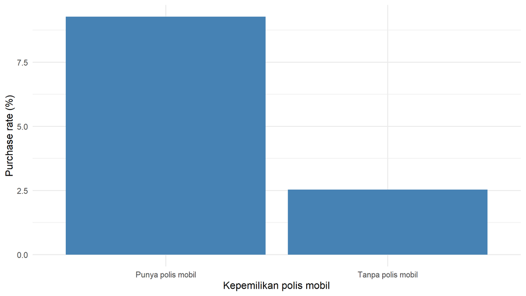

```r
ggplot(rate_mobil, aes(x = mobil, y = persen)) +
  geom_col(fill = "steelblue") +
  labs(x = "Kepemilikan polis mobil", y = "Purchase rate (%)") +
  theme_minimal()
```

**Pola hafalan:** data → `ggplot(aes(x, y))` → `geom_col()`.

**Mengapa cocok:** perbandingan memakai purchase rate, bukan jumlah pembeli mentah. Kelompok yang lebih besar tidak otomatis mempunyai rate lebih tinggi. Tabel menampilkan jumlah pelanggan dan pembeli agar dukungan datanya terlihat.

**Interpretasi hasil:** pelanggan dengan polis mobil memiliki purchase rate **9.27%** pada **2977 pelanggan**, sedangkan kelompok tanpa polis mobil **2.53%** pada **2845 pelanggan**. Perbedaannya **6.74 poin persentase**. Kepemilikan polis mobil dapat dipertimbangkan sebagai karakteristik untuk pengujian penawaran silang bila rate-nya lebih tinggi, tetapi hubungan ini tidak membuktikan bahwa polis mobil menyebabkan pembelian caravan.

### Grafik 2 — Boxplot kelas daya beli menurut Purchase

**Pertanyaan:** apakah nilai tengah dan penyebaran kelas daya beli berbeda antara pembeli dan bukan pembeli?

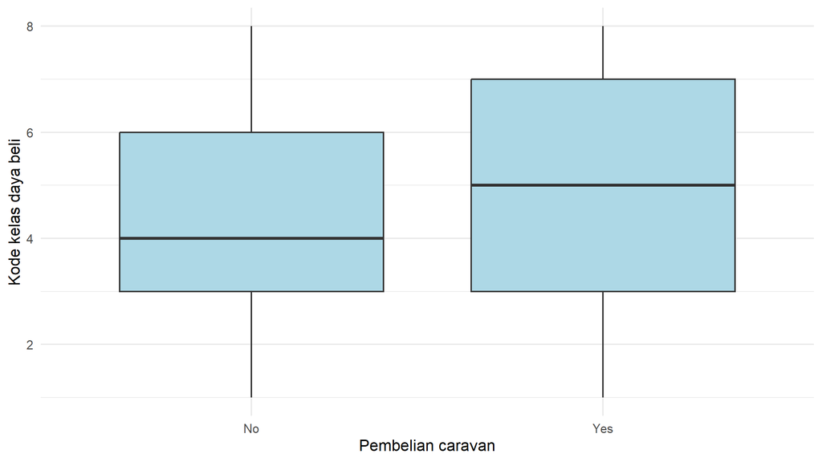

```r
ggplot(dat, aes(x = Purchase, y = purchasing_power_class)) +
  geom_boxplot(fill = "lightblue") +
  labs(x = "Pembelian caravan", y = "Kode kelas daya beli") +
  theme_minimal()
```

**Pola hafalan:** kategori pada x, numerik pada y → `geom_boxplot()`.

**Mengapa cocok:** membandingkan median, rentang tengah 50% data (IQR), dan nilai di luar whisker tanpa hanya mengandalkan mean. purchasing_power_class berupa kode ordinal; jarak antarkode diperlakukan sebagai skor, bukan rupiah.

```r
daya_beli = dat %>%
  group_by(Purchase) %>%
  summarise(mean = mean(purchasing_power_class), median = median(purchasing_power_class),
            IQR = IQR(purchasing_power_class), .groups = "drop")
daya_beli
```

```
## # A tibble: 2 × 4
##   Purchase  mean median   IQR
##   <fct>    <dbl>  <dbl> <dbl>
## 1 No        4.19      4     3
## 2 Yes       5         5     4
```

**Interpretasi:** bandingkan median dan IQR pada tabel dengan boxplot. Jika median atau rentang kedua kelompok berbeda, ada perbedaan deskriptif profil daya beli. Jika kotak banyak bertumpuk, daya beli saja belum memisahkan pembeli secara jelas. Titik di luar whisker tidak otomatis merupakan kesalahan data. Perbedaan ini tidak membuktikan pengaruh kausal daya beli terhadap pembelian.

### Grafik 3 — Histogram kontribusi polis mobil, satu panel per kelas

**Pertanyaan:** apakah pembeli dan bukan pembeli berbeda dalam dominasi nol dan pola kode kontribusi polis mobil?

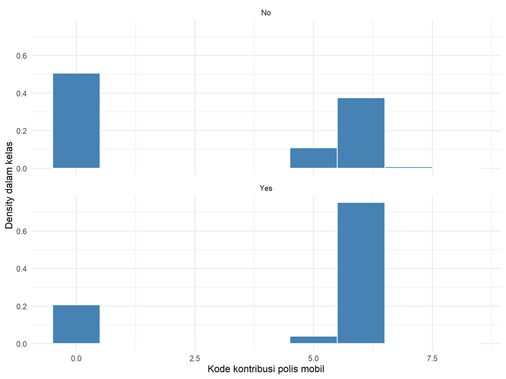

```r
ggplot(dat, aes(x = contribution_car_policies)) +
  geom_histogram(aes(y = after_stat(density)), binwidth = 1,
                 boundary = -0.5, fill = "steelblue", color = "white") +
  facet_wrap(~ Purchase, ncol = 1) +
  labs(x = "Kode kontribusi polis mobil", y = "Density dalam kelas") +
  theme_minimal()
```

**Pola hafalan:** numerik pada x → `geom_histogram()` → `facet_wrap(~ Purchase)` untuk memisahkan kelas.

**Mengapa ada `after_stat(density)`?** Yes jauh lebih sedikit daripada No. Density menormalkan histogram di setiap kelas sehingga bentuk distribusi dapat dibandingkan, tidak sekadar membandingkan jumlah pelanggan. Luas batang pada masing-masing kelas berjumlah 1. Sumbu y bukan jumlah pelanggan.

`binwidth = 1` dan `boundary = -0.5` menempatkan setiap kode bilangan bulat dalam satu bin. Ini histogram untuk skor diskrit; jangan mengartikan nilai di antara kode sebagai nominal premi yang benar-benar diamati.

```r
profil_mobil = dat %>%
  group_by(Purchase) %>%
  summarise(mean = mean(contribution_car_policies), median = median(contribution_car_policies),
            persen_nol = 100 * mean(contribution_car_policies == 0), .groups = "drop")
profil_mobil
```

```
## # A tibble: 2 × 4
##   Purchase  mean median persen_nol
##   <fct>    <dbl>  <dbl>      <dbl>
## 1 No        2.86      0       50.7
## 2 Yes       4.72      6       20.7
```

**Interpretasi:** periksa apakah batang pada kode 0 lebih dominan di salah satu kelas dan apakah kelas lain lebih terkonsentrasi pada kode lebih tinggi. Gunakan tabel untuk memeriksa persentase nol dan median. Bila mean berbeda tetapi median sama, mean saja belum cukup menjelaskan distribusi. Kode kontribusi adalah kategori kontribusi, bukan rupiah, dan perbedaan distribusi bukan bukti kausal.

**Strategi menjawab:** setiap grafik ditulis dengan pola **pertanyaan → alasan bentuk grafik → hasil yang terlihat → implikasi bisnis → keterbatasan**. Jangan membuat kesimpulan sebelum membaca output.

### Alternatif visualisasi lainnya — kode sederhana dan dijalankan

**Semua alternatif berikut tampil saat Knit.** Tujuannya latihan memilih grafik sesuai pertanyaan, bukan menghafal satu bentuk grafik. Kode memakai kolom langsung, `ggplot()`, dan ringkasan kelompok singkat. Untuk jawaban ujian Tugas 2(b), pilih maksimal tiga grafik paling informatif dari seluruh pilihan; dokumen belajar ini sengaja menampilkan lebih banyak grafik.

| Pilihan | Pertanyaan | Bentuk grafik |
| --- | --- | --- |
| 1 | Apakah purchase rate berbeda antar-kelas pendapatan? | Bar plot rate |
| 2 | Apakah purchase rate berbeda antar-kategori usia wilayah? | Bar plot rate |
| 3 | Apakah kontribusi polis kebakaran berbeda pada pembeli? | Boxplot |
| 4 | Apakah pola kelas daya beli berbeda, termasuk nilai yang dominan? | Histogram per kelas |
| 5 | Apakah pembeli menempati kombinasi pendapatan–daya beli tertentu? | Scatter/jitter plot |
| 6 | Apakah komposisi Yes/No berbeda menurut jumlah polis mobil? | Bar plot proporsi bertumpuk |
| 7 | Bagaimana rate pada kombinasi kepemilikan polis mobil/kebakaran? | Heatmap rate |
| 8 | Apakah subtype pelanggan yang umum mempunyai rate berbeda? | Bar plot horizontal |
| 9 | Bagaimana seluruh distribusi kontribusi mobil berbeda antarkelas? | Kurva distribusi kumulatif (ECDF) |

#### Alternatif 1 — Bar plot purchase rate menurut pendapatan

**Pertanyaan:** apakah kelas pendapatan bisa menjadi indikator awal pembelian?

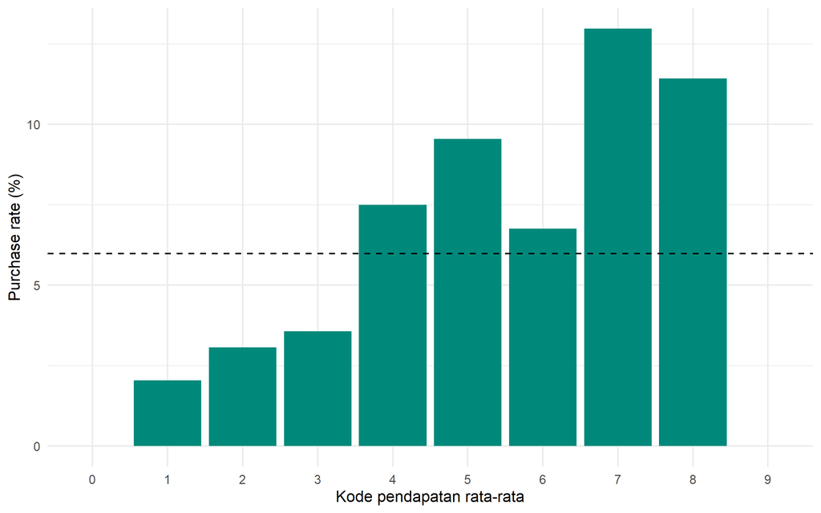

```r
rate_income_plot = dat %>% group_by(average_income) %>%
  summarise(jumlah = n(), pembeli = sum(Purchase == "Yes"),
            persen = 100 * mean(Purchase == "Yes"), .groups = "drop")

ggplot(rate_income_plot, aes(x = factor(average_income), y = persen)) +
  geom_col(fill = "#00897B") +
  geom_hline(yintercept = 100 * rate_all, linetype = "dashed") +
  labs(x = "Kode pendapatan rata-rata", y = "Purchase rate (%)") + theme_minimal()
```

```r
rate_income_plot
```

```
## # A tibble: 10 × 4
##    average_income jumlah pembeli persen
##             <dbl>  <int>   <int>  <dbl>
##  1              0     25       0   0
##  2              1     49       1   2.04
##  3              2    651      20   3.07
##  4              3   1932      69   3.57
##  5              4   1854     139   7.50
##  6              5    733      70   9.55
##  7              6    355      24   6.76
##  8              7    131      17  13.0
##  9              8     70       8  11.4
## 10              9     22       0   0
```

**Interpretasi:** batang di atas garis putus-putus memiliki rate di atas rata-rata data. Periksa jumlah pelanggan/pembeli pada tabel sebelum memilih kategori; rate tertinggi pada kelompok kecil belum cukup untuk targeting. Kode pendapatan bukan rupiah, dan asosiasi bukan bukti pendapatan menyebabkan pembelian.

#### Alternatif 2 — Bar plot purchase rate menurut kategori usia

**Pertanyaan:** apakah kelompok profil usia wilayah memiliki tingkat pembelian berbeda?

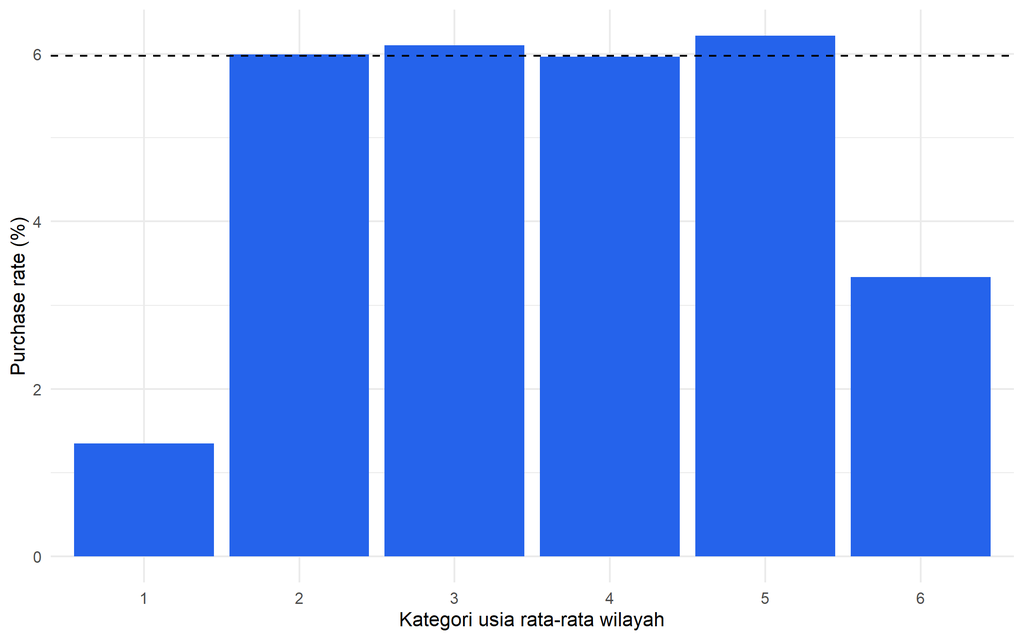

```r
rate_age_plot = dat %>% group_by(average_age_category) %>%
  summarise(jumlah = n(), pembeli = sum(Purchase == "Yes"),
            persen = 100 * mean(Purchase == "Yes"), .groups = "drop")

ggplot(rate_age_plot, aes(x = factor(average_age_category), y = persen)) +
  geom_col(fill = "#2563EB") +
  geom_hline(yintercept = 100 * rate_all, linetype = "dashed") +
  labs(x = "Kategori usia rata-rata wilayah", y = "Purchase rate (%)") + theme_minimal()
```

```r
rate_age_plot
```

```
## # A tibble: 6 × 4
##   average_age_category jumlah pembeli persen
##                  <dbl>  <int>   <int>  <dbl>
## 1                    1     74       1   1.35
## 2                    2   1452      87   5.99
## 3                    3   3000     183   6.1
## 4                    4   1073      64   5.96
## 5                    5    193      12   6.22
## 6                    6     30       1   3.33
```

**Interpretasi:** bandingkan rate, ukuran kelompok, dan jumlah pembeli. Jangan langsung menyebut kode kategori sebagai umur dalam tahun. Karakteristik usia merupakan profil wilayah, bukan usia pasti individu; pola historis dapat menjadi hipotesis pesan pemasaran yang perlu diuji.

#### Alternatif 3 — Boxplot kontribusi polis kebakaran

**Pertanyaan:** apakah pembeli caravan mempunyai profil kontribusi kebakaran yang berbeda?

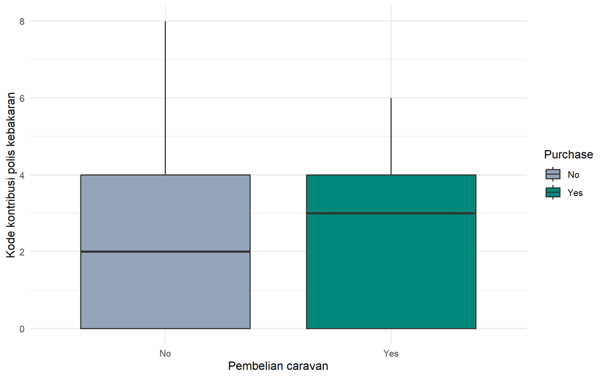

```r
ggplot(dat, aes(x = Purchase, y = contribution_fire_policies, fill = Purchase)) +
  geom_boxplot(outlier.alpha = 0.15) +
  scale_fill_manual(values = c(No = "#94A3B8", Yes = "#00897B")) +
  labs(x = "Pembelian caravan", y = "Kode kontribusi polis kebakaran") + theme_minimal()
```

**Interpretasi:** bandingkan median, IQR, dan tumpang tindih. Median sama belum berarti distribusinya identik. Banyak nilai nol dapat membuat kotak pendek; nilai di luar whisker tidak otomatis salah. Ini kode kontribusi, bukan besaran premi rupiah; belum membuktikan manfaat penawaran silang.

#### Alternatif 4 — Histogram kelas daya beli per Purchase

**Pertanyaan:** apakah pembeli lebih terkonsentrasi pada kode daya beli tertentu?

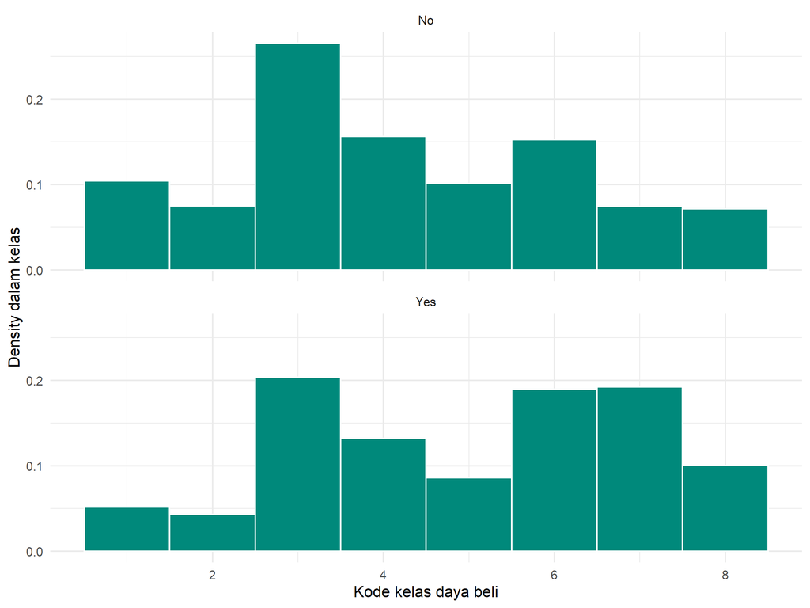

```r
ggplot(dat, aes(x = purchasing_power_class)) +
  geom_histogram(aes(y = after_stat(density)), binwidth = 1, boundary = -0.5,
                 fill = "#00897B", color = "white") +
  facet_wrap(~ Purchase, ncol = 1) +
  labs(x = "Kode kelas daya beli", y = "Density dalam kelas") + theme_minimal()
```

**Interpretasi:** density membuat bentuk dua kelas dapat dibandingkan meskipun jumlah No jauh lebih besar. Dengan binwidth 1, setiap kode integer berada pada bin tersendiri. Bandingkan puncak dan penyebaran, bukan jumlah pelanggan mentah. Daya beli berkode ordinal, bukan pengukuran kontinu rupiah.

#### Alternatif 5 — Kombinasi pendapatan dan daya beli

**Pertanyaan:** apakah profil pendapatan–daya beli pembeli terlihat terpisah dari bukan pembeli?

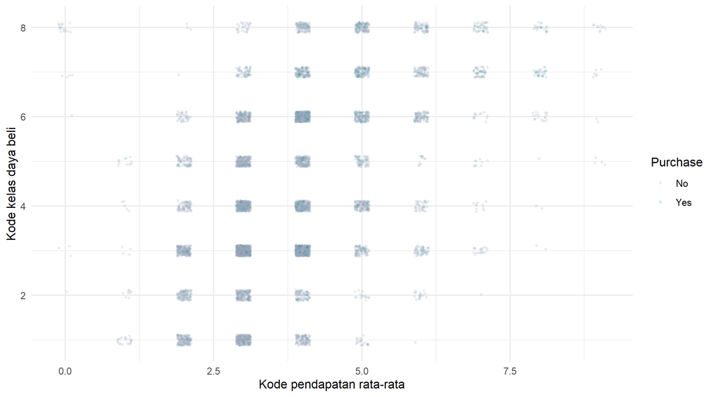

```r
set.seed(88)
ggplot(dat, aes(x = average_income, y = purchasing_power_class, color = Purchase)) +
  geom_jitter(width = 0.12, height = 0.12, alpha = 0.15, size = 0.8) +
  scale_color_manual(values = c(No = "#94A3B8", Yes = "#00897B")) +
  labs(x = "Kode pendapatan rata-rata", y = "Kode kelas daya beli") + theme_minimal()
```

**Interpretasi:** lihat tumpang tindih dan hubungan dua indikator. Jitter hanya menggeser tampilan agar titik terlihat, bukan mengubah data atau menciptakan nilai pendapatan baru. Titik No lebih banyak karena ukuran kelas berbeda; kegelapan bukan purchase rate. Jika banyak tumpang tindih, dua indikator ini belum memisahkan pembeli secara jelas dan tidak membuktikan hubungan kausal.

#### Alternatif 6 — Proporsi Purchase menurut jumlah polis mobil

**Pertanyaan:** apakah komposisi pembeli berbeda antara pelanggan tanpa, satu, atau beberapa polis mobil?

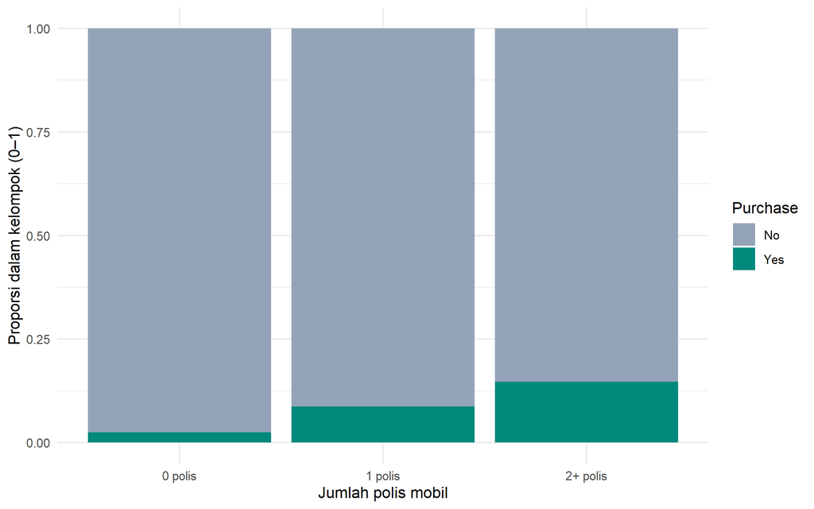

```r
polis_plot = dat %>%
  mutate(polis_mobil = ifelse(number_of_car_policies == 0, "0 polis",
    ifelse(number_of_car_policies == 1, "1 polis", "2+ polis")))

ggplot(polis_plot, aes(x = polis_mobil, fill = Purchase)) +
  geom_bar(position = "fill") +
  scale_fill_manual(values = c(No = "#94A3B8", Yes = "#00897B")) +
  labs(x = "Jumlah polis mobil", y = "Proporsi dalam kelompok (0–1)") + theme_minimal()
```

```r
polis_plot %>% group_by(polis_mobil) %>%
  summarise(jumlah = n(), pembeli = sum(Purchase == "Yes"),
            persen = 100 * mean(Purchase == "Yes"), .groups = "drop")
```

```
## # A tibble: 3 × 4
##   polis_mobil jumlah pembeli persen
##   <chr>        <int>   <int>  <dbl>
## 1 0 polis       2845      72   2.53
## 2 1 polis       2712     237   8.74
## 3 2+ polis       265      39  14.7
```

**Interpretasi:** tinggi bagian Yes menunjukkan proporsi pembeli dalam masing-masing kelompok polis; seluruh batang berjumlah 1. Gunakan tabel untuk rate yang tepat serta jumlah pelanggan. Kelompok 2+ tidak otomatis lebih baik daripada satu polis; baca hasilnya, jangan berasumsi peningkatan selalu monoton.

#### Alternatif 7 — Heatmap kombinasi produk mobil dan kebakaran

**Pertanyaan:** apakah pelanggan yang memiliki kedua jenis produk mempunyai rate historis berbeda?

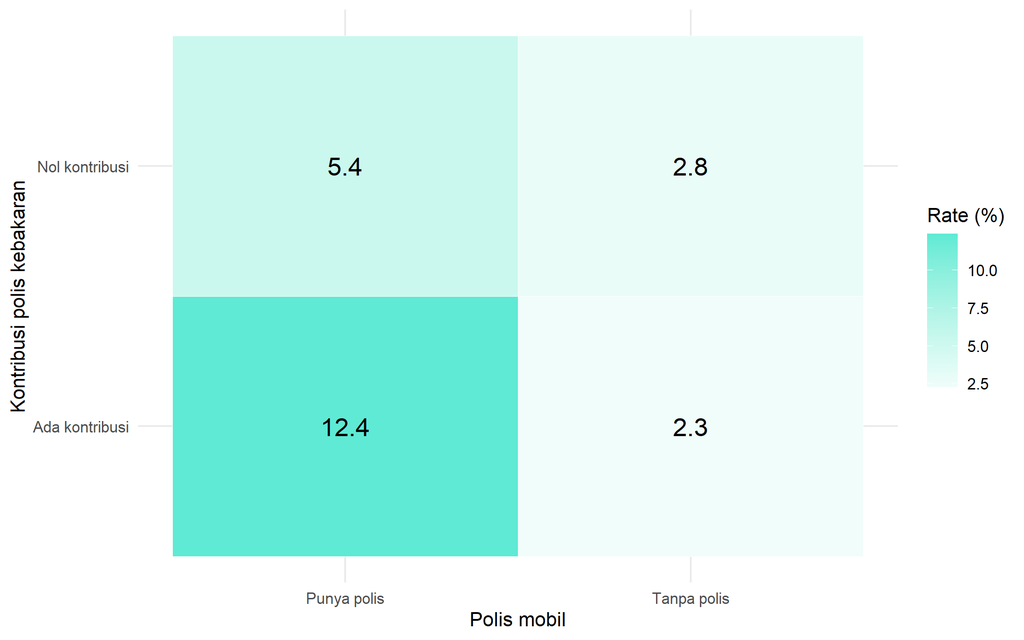

```r
rate_produk_plot = dat %>%
  mutate(mobil = ifelse(number_of_car_policies > 0, "Punya polis", "Tanpa polis"),
         kebakaran = ifelse(contribution_fire_policies > 0, "Ada kontribusi", "Nol kontribusi")) %>%
  group_by(mobil, kebakaran) %>%
  summarise(jumlah = n(), pembeli = sum(Purchase == "Yes"),
            persen = 100 * mean(Purchase == "Yes"), .groups = "drop")

ggplot(rate_produk_plot, aes(x = mobil, y = kebakaran, fill = persen)) +
  geom_tile(color = "white") +
  geom_text(aes(label = round(persen, 1)), size = 5) +
  scale_fill_gradient(low = "#F0FDFA", high = "#5EEAD4") +
  labs(x = "Polis mobil", y = "Kontribusi polis kebakaran", fill = "Rate (%)") + theme_minimal()
```

```r
rate_produk_plot
```

```
## # A tibble: 4 × 5
##   mobil       kebakaran      jumlah pembeli persen
##   <chr>       <chr>           <int>   <int>  <dbl>
## 1 Punya polis Ada kontribusi   1654     205  12.4
## 2 Punya polis Nol kontribusi   1323      71   5.37
## 3 Tanpa polis Ada kontribusi   1502      34   2.26
## 4 Tanpa polis Nol kontribusi   1343      38   2.83
```

**Interpretasi:** angka sel adalah purchase rate (%), dan tabel menunjukkan dukungan jumlah pelanggan/pembeli. Label “Punya polis” berarti mempunyai **polis mobil**, bukan kepastian kepemilikan kendaraan. Kombinasi rate tinggi dapat menjadi hipotesis penawaran silang, bukan bukti kenaikan penjualan karena kampanye. Ini eksplorasi dua variabel; Tugas 2(c) tetap menggunakan satu variabel segmentasi.

#### Alternatif 8 — Bar plot subtype paling umum

**Pertanyaan:** apakah kategori nominal dengan banyak pelanggan mempunyai rate berbeda?

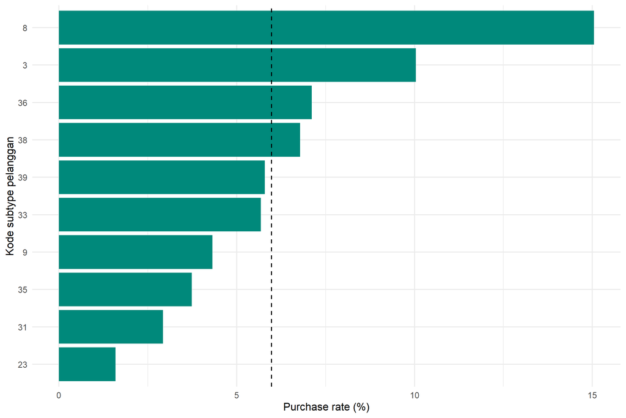

```r
rate_subtype_plot = dat %>% group_by(customer_subtype) %>%
  summarise(jumlah = n(), pembeli = sum(Purchase == "Yes"),
            persen = 100 * mean(Purchase == "Yes"), .groups = "drop") %>%
  arrange(desc(jumlah), customer_subtype) %>% slice_head(n = 10)

ggplot(rate_subtype_plot, aes(x = reorder(customer_subtype, persen), y = persen)) +
  geom_col(fill = "#00897B") + coord_flip() +
  geom_hline(yintercept = 100 * rate_all, linetype = "dashed") +
  labs(x = "Kode subtype pelanggan", y = "Purchase rate (%)") + theme_minimal()
```

```r
rate_subtype_plot
```

```
## # A tibble: 10 × 4
##    customer_subtype jumlah pembeli persen
##    <fct>             <int>   <int>  <dbl>
##  1 33                  810      46   5.68
##  2 8                   339      51  15.0
##  3 38                  339      23   6.78
##  4 39                  328      19   5.79
##  5 9                   278      12   4.32
##  6 23                  251       4   1.59
##  7 3                   249      25  10.0
##  8 36                  225      16   7.11
##  9 35                  214       8   3.74
## 10 31                  205       6   2.93
```

**Interpretasi:** sepuluh subtype dipilih dari jumlah pelanggan terbesar, bukan rate tertinggi. Kode nominal tidak menyatakan urutan kualitas pelanggan. Baca dukungan pembeli pada tabel dan cari makna kategori pada kamus sebelum merancang pesan; grafik ini tidak mencakup seluruh subtype.

#### Alternatif 9 — ECDF kontribusi polis mobil

**Pertanyaan:** apakah perbedaan kelompok terlihat di seluruh distribusi, bukan mean saja?

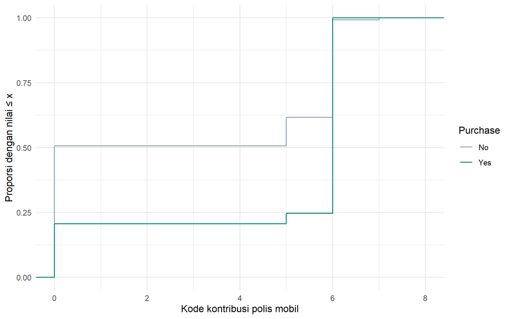

```r
ggplot(dat, aes(x = contribution_car_policies, color = Purchase)) +
  stat_ecdf(geom = "step") +
  scale_color_manual(values = c(No = "#94A3B8", Yes = "#00897B")) +
  labs(x = "Kode kontribusi polis mobil", y = "Proporsi dengan nilai ≤ x") + theme_minimal()
```

**Interpretasi:** ECDF adalah kurva proporsi kumulatif. Pada x yang sama, kurva lebih rendah berarti lebih sedikit pelanggan mempunyai nilai ≤x, sehingga relatif lebih banyak berada di kode yang lebih tinggi. Kurva bertumpuk menunjukkan distribusi serupa; kurva berpotongan menunjukkan perbedaan yang tidak cukup dijelaskan oleh mean. Kurva ini sudah memakai proporsi dalam kelas, sehingga tidak didominasi jumlah No.

**Strategi memilih grafik final:** satu grafik rate bisnis, satu grafik distribusi, lalu satu grafik yang menjawab pertanyaan berbeda. Untuk tiap grafik: tulis pertanyaan → alasan bentuk grafik → hasil → implikasi bisnis → keterbatasan. Sembilan alternatif di sini dijalankan untuk latihan; pangkas pilihan menjadi maksimal tiga ketika menyusun jawaban ujian.

## (c) Segmentasi awal berbasis bisnis (6 poin)

### Rekomendasi variabel: purchasing_power_class (kelas daya beli)

Variabel ini dapat diterjemahkan menjadi kelompok kelas daya beli yang mudah dikomunikasikan. Gunakan kode asli terlebih dahulu agar tidak membuat batas kelompok sembarangan. Boxplot pada grafik 2 membandingkan daya beli menurut Purchase. Pada bagian (c), pelanggan dikelompokkan berdasarkan **satu variabel purchasing_power_class**, lalu purchase rate dihitung pada setiap kelas daya beli.

```r
segmen = dat %>%
  group_by(purchasing_power_class) %>%
  summarise(jumlah = n(), pembeli = sum(Purchase == "Yes"),
            rate = mean(Purchase == "Yes"), .groups = "drop") %>%
  mutate(persen = 100 * rate, lift = rate / rate_all) %>%
  arrange(desc(rate))
segmen
```

```
## # A tibble: 8 × 6
##   purchasing_power_class jumlah pembeli   rate persen  lift
##                    <dbl>  <int>   <int>  <dbl>  <dbl> <dbl>
## 1                      7    474      67 0.141   14.1  2.36
## 2                      8    426      35 0.0822   8.22 1.37
## 3                      6    901      66 0.0733   7.33 1.23
## 4                      5    583      30 0.0515   5.15 0.861
## 5                      4    902      46 0.0510   5.10 0.853
## 6                      3   1524      71 0.0466   4.66 0.779
## 7                      2    425      15 0.0353   3.53 0.590
## 8                      1    587      18 0.0307   3.07 0.513
```

**Hasil segmentasi:** kelompok dengan rate tertinggi adalah kode **7**, berisi **474 pelanggan** dan **67 pembeli**. Purchase rate-nya **14.14%**, dibanding **5.98%** seluruh data, dengan lift deskriptif **2.36 kali**.

**Rekomendasi:** purchasing_power_class dapat dipakai sebagai indikator awal untuk membandingkan kelompok dan merancang pilot pemasaran, tetapi belum cukup sebagai penentu tunggal. Perhatikan dukungan jumlah pelanggan/pembeli dan seluruh pola rate pada tabel, bukan hanya kategori tertinggi. Perbedaan historis ini perlu divalidasi pada data baru.

**Kriteria rekomendasi:** bandingkan rate dengan rata-rata seluruh data, cek jumlah pelanggan dan pembeli, serta perhatikan apakah hubungan meningkat konsisten atau tidak. Jangan memilih kategori hanya karena rate tertinggi jika dukungan datanya sangat sedikit.

**Pola jawaban jika ingin menulis sendiri:**

> Saya memilih purchasing_power_class sebagai dasar segmentasi awal karena kelas daya beli mudah dipahami tim pemasaran. Kelompok [kode] berisi [jumlah] pelanggan dengan purchase rate [persen]%, dibanding rata-rata [persen]% seluruh data. Lift deskriptifnya [angka] kali. Variabel ini [layak/belum cukup] sebagai indikator awal karena [perbedaan rate dan dukungan jumlah pelanggan]. Temuan belum membuktikan hubungan sebab-akibat. Targeting akhir perlu model prediksi dan validasi pada data baru; rate dari seluruh data ini bersifat eksploratif.

Jika rate tidak berbeda banyak atau tidak stabil, simpulkan variabel belum cukup sebagai indikator tunggal. Jangan menganggap kode daya beli lebih tinggi selalu berarti rate pembelian lebih tinggi.

# Tugas 3 (15 poin): Reduksi Dimensi dan Clustering

| Subnomor | Penjelasan | Solusi | Fungsi Utama |
| --- | --- | --- | --- |
| (a).1 | Anda diminta PCA dan alasan standardisasi. | Pilih numerik lolos audit; lakukan PCA dengan standardisasi. | `select()`, `prcomp(scale.=TRUE)` |
| (a).2 | Anda diminta jumlah PC untuk minimal 70% variasi. | Ambil tabel eigenvalue; pilih PC pertama yang kumulatifnya ≥70%. | `get_eigenvalue()`, `which()` |
| (a).3 | Anda diminta loading absolut terbesar PC1/PC2. | Ambil rotation, cari nilai absolut terbesar, lalu baca tanda aslinya. | `pca$rotation`, `abs()`, `which.max()` |
| (a).4 | Anda diminta keterbatasan PCA. | Jelaskan skala kode, profil wilayah, kombinasi linear, dan variansi bukan relevansi target. | Tabel loading dan makna variabel |
| (b).1–2 | Anda diminta k=2,…,6 dan ukuran kualitas. | Gunakan skor PC ≥70%; tampilkan WSS dan silhouette. | `pca$x`, `fviz_nbclust()` |
| (b).3 | Anda diminta memilih k yang masuk akal. | Pilih silhouette terbesar untuk k=2–6; periksa elbow/ukuran dan fit k terpilih. | `which.max()`, `kmeans()` |
| (b).4–5 | Anda diminta Purchase antar-cluster dan insight bisnis. | Setelah fitting, hitung rate serta profil; jelaskan rate + ukuran + karakteristik. | `table()`, `prop.table()`, `summarise()` |

**Alur hafalan:** numerik → PCA → eigenvalue ≥70% → skor PC → pilih k → cluster → purchase rate. Purchase tidak dipakai membentuk PCA/cluster.

## (a) PCA (7 poin)

### 1. Input dan standardisasi

```r
hampir_nol = audit_var %>% filter(dominan >= 0.95, unik > 1) %>% pull(variabel)
dat_pca = dat %>% select(where(is.numeric)) %>% select(-any_of(hampir_nol))
pca = prcomp(dat_pca, scale. = TRUE)
```

**Jawaban:** target dan customer_subtype sudah faktor sehingga tidak ikut input numerik; konstan sudah dikeluarkan pada Tugas 1. Dominasi ≥95% dikeluarkan khusus PCA. Standardisasi diperlukan karena skala/varians berbeda; tanpa itu, variabel bervarians besar dapat mendominasi PCA dan jarak K-means. `scale.=TRUE` memusatkan dan membuat SD input satu.

### 2. Jumlah PC minimal 70%

```r
eigenvalue = get_eigenvalue(pca)
jumlah_pc = which(eigenvalue$cumulative.variance.percent >= 70)[1]
eigenvalue
```

```
##          eigenvalue variance.percent cumulative.variance.percent
## Dim.1  3.2628419879     25.098784523                    25.09878
## Dim.2  1.9332278410     14.870983392                    39.96977
## Dim.3  1.4644347264     11.264882511                    51.23465
## Dim.4  1.2628698807      9.714383698                    60.94903
## Dim.5  1.0994336580      8.457181985                    69.40622
## Dim.6  0.9862473020      7.586517708                    76.99273
## Dim.7  0.8874866025      6.826820019                    83.81955
## Dim.8  0.6412648505      4.932806542                    88.75236
## Dim.9  0.5401809483      4.155238064                    92.90760
## Dim.10 0.4613606732      3.548928256                    96.45653
## Dim.11 0.3765727982      2.896713832                    99.35324
## Dim.12 0.0836414555      0.643395812                    99.99664
## Dim.13 0.0004372757      0.003363659                   100.00000
```

```r
jumlah_pc
```

```
## [1] 6
```

**Hasil:** diperlukan **6 PC pertama**, menjelaskan **76.99%** variasi. Ambil komponen pertama yang mencapai ≥70%; jangan membulatkan 69,x% menjadi 70%.

### 3. Loading PC1 dan PC2

```r
loading = pca$rotation
v1 = rownames(loading)[which.max(abs(loading[, 1]))]
v2 = rownames(loading)[which.max(abs(loading[, 2]))]
loading[c(v1, v2), 1:2]
```

```
##                                   PC1        PC2
## rented_house              -0.47290890 -0.0569490
## contribution_car_policies  0.04495126 -0.6964387
```

**Hasil:** PC1 mempunyai loading absolut terbesar pada **rented_house** (loading **-0.473**); PC2 pada **contribution_car_policies** (loading **-0.696**). Besar absolut menunjukkan kontribusi; tanda menunjukkan arah/kontras pada PC, bukan efek terhadap peluang membeli.

### 4. Keterbatasan interpretasi

Kode ordinal dianggap berjarak numerik sama, dan profil wilayah belum tentu menggambarkan individu. PC adalah kombinasi linear; variasi besar belum tentu relevan terhadap Purchase. Pemakaian sebagian PC dan pengeluaran fitur sangat jarang dapat menghilangkan informasi/segmen niche. PCA tidak membuktikan hubungan sebab-akibat.

## (b) K-means pada skor PCA (8 poin)

### 1. Skor PC dan kandidat k

```r
skor_pc = data.frame(pca$x[, 1:jumlah_pc, drop = FALSE])
```

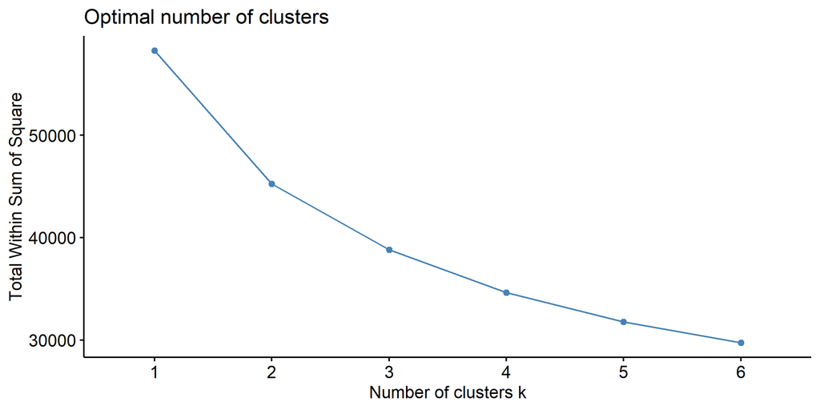

```r
set.seed(123)
plot_wss = fviz_nbclust(skor_pc, kmeans, method = "wss", k.max = 6, nstart = 25)
plot_wss
```

```r
plot_wss$data
```

```
##   clusters        y
## 1        1 58262.71
## 2        2 45261.74
## 3        3 38803.78
## 4        4 34638.05
## 5        5 31774.96
## 6        6 29739.39
```

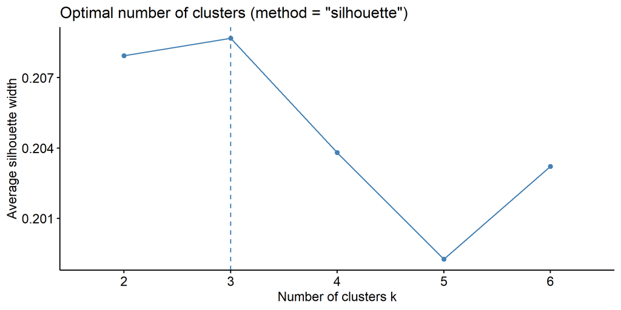

```r
set.seed(123)
plot_silhouette = fviz_nbclust(skor_pc, kmeans, method = "silhouette", k.max = 6, nstart = 25)
plot_silhouette
```

```r
plot_silhouette$data
```

```
##   clusters         y
## 1        2 0.2079418
## 2        3 0.2086812
## 3        4 0.2038061
## 4        5 0.1992676
## 5        6 0.2032193
```

**Cara membaca:** bandingkan k=2–6. WSS makin kecil berarti lebih kompak tetapi biasanya turun ketika k bertambah; cari elbow. Silhouette mendekati 1 berarti lebih terpisah, sekitar 0 tumpang tindih, negatif kurang sesuai. K=1 pada WSS hanya baseline, bukan kandidat jawaban.

### 2. Pilih k dan fit cluster

```r
hasil_k = plot_silhouette$data %>% filter(clusters %in% 2:6)
best_k = as.numeric(as.character(hasil_k$clusters[which.max(hasil_k$y)]))
set.seed(123)
km = kmeans(skor_pc, centers = best_k, nstart = 25)
table(km$cluster)
```

```
##
##    1    2    3
## 1862 1838 2122
```

```r
sil_final = mean(cluster::silhouette(km$cluster, dist(skor_pc))[, 3])
sil_final
```

```
## [1] 0.2086812
```

**Hasil:** dipilih **k=3** berdasarkan silhouette kandidat tertinggi; silhouette model final **0.209**, cluster terkecil **1838 pelanggan**. Periksa elbow dan ukuran sebelum menyebutnya layak. Jika kualitas rendah atau kandidat hampir seri, laporkan ketidakpastian. Jangan memilih k dari purchase rate.

### 3. Visualisasi cluster

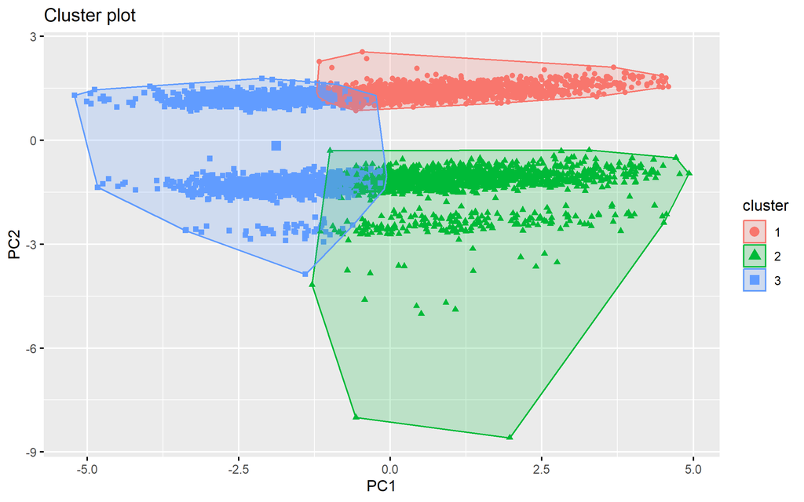

```r
fviz_cluster(km, data = skor_pc, choose.vars = c("PC1", "PC2"),
             stand = FALSE, geom = "point")
```

Gambar memakai PC1/PC2 asli tanpa standardisasi ulang. K-means memakai seluruh `jumlah_pc` PC; tumpang tindih pada dua sumbu belum tentu berarti cluster gagal pada ruang lengkap.

### 4. Purchase dan profil cluster

```r
segmen_cluster = dat %>% mutate(cluster = factor(km$cluster))
tabel_cluster = table(Cluster = segmen_cluster$cluster, Purchase = segmen_cluster$Purchase)
round(100 * prop.table(tabel_cluster, 1), 2)
```

```
##        Purchase
## Cluster    No   Yes
##       1 96.89  3.11
##       2 88.52 11.48
##       3 96.28  3.72
```

```r
ringkasan_cluster = segmen_cluster %>% group_by(cluster) %>%
  summarise(jumlah = n(), pembeli = sum(Purchase == "Yes"), rate = mean(Purchase == "Yes"),
            contribution_car_policies = mean(contribution_car_policies),
            purchasing_power_class = mean(purchasing_power_class), .groups = "drop") %>%
  mutate(persen_beli = 100 * rate, lift = rate / rate_all) %>% arrange(desc(rate))
ringkasan_cluster
```

```
## # A tibble: 3 × 8
##   cluster jumlah pembeli   rate contribution_car_policies purchasing_power_class
##   <fct>    <int>   <int>  <dbl>                     <dbl>                  <dbl>
## 1 2         1838     211 0.115                       5.87                   5.01
## 2 3         2122      79 0.0372                      3.07                   2.97
## 3 1         1862      58 0.0311                      0                      4.91
## # ℹ 2 more variables: persen_beli <dbl>, lift <dbl>
```

```r
cluster_top = ringkasan_cluster[1, ]
```

**Insight bisnis:** cluster **2** memiliki rate tertinggi **11.48%** pada **1838 pelanggan** dan **211 pembeli**, dengan lift deskriptif **1.92 kali**. Rata-rata kode kontribusi mobilnya **5.87** dan kelas daya beli **5.01**; bandingkan profil dengan cluster lain. Segmen ini kandidat pilot penawaran, belum bukti efek kampanye. Simpan cluster terpisah agar tidak ikut GLM/tree.

# Tugas 4 (20 poin): Regresi Logistik untuk Propensity Modelling

| Subnomor | Penjelasan | Solusi | Fungsi Utama |
| --- | --- | --- | --- |
| (a), 4 poin | Anda diminta split stratified sekitar 70:30. | Ambil 70% tiap kelas dengan seed; sisanya test; cek prevalensi. | `slice_sample()`, `anti_join()` |
| (b), 6 poin | Anda diminta fit GLM dan minimal dua OR bisnis. | Pilih kandidat layak; fit penuh; stepwise AIC dengan dua produk inti; baca OR. | `glm()`, `step()`, `exp(coef())` |
| (c), 6 poin | Anda diminta AUC, recall, specificity, precision, confusion matrix, dan threshold training. | Prediksi training; pilih threshold Youden; evaluasi test. Undersampling hanya pembanding training. | `predict()`, `pilih_threshold()`, `evaluasi_model()` |
| (d), 4 poin | Anda diminta capture/lift pada top20. | Ranking probabilitas; ambil kuota 20%; hitung capture/lift dan jelaskan relevansinya. | `arrange()`, `slice_head()`, `sum()`, `mean()` |

**Alur hafalan:** split → GLM penuh → stepwise → OR → evaluasi → pembanding undersampling → top20. Semua fitting/seleksi/threshold memakai training; test tetap asli.

## (a) Pembagian data (4 poin)

```r
dat_model = dat %>% mutate(id = row_number())
set.seed(123)
train = dat_model %>% group_by(Purchase) %>% slice_sample(prop = 0.7) %>% ungroup()
test = dat_model %>% anti_join(train, by = "id")
prop.table(table(train$Purchase))
```

```
##
##         No        Yes
## 0.94035346 0.05964654
```

```r
prop.table(table(test$Purchase))
```

```
##
##         No        Yes
## 0.93993135 0.06006865
```

**Jawaban:** training **4074 pelanggan**, test **1748 pelanggan**. Stratifikasi mempertahankan keterwakilan Yes yang jarang; tidak mengubah distribusi menjadi 50:50. ID hanya penanda baris, bukan prediktor.

## (b) Fitting model (6 poin)

### 1. Kandidat, GLM penuh, dan stepwise

```r
train_glm = train %>% select(-id, -customer_subtype, -rented_house, -number_of_car_policies)
variabel_glm = setdiff(names(train_glm), "Purchase")
```

**Keputusan:** gunakan 11 kandidat numerik dari 14 prediktor. Customer subtype dikeluarkan untuk model ringkas tanpa kategori jarang; rented_house tidak dipakai bersama home_owners, dan jumlah polis mobil tidak dipakai bersama kontribusinya karena informasi sangat berkaitan. Skor ordinal dianggap berefek linear pada log-odds; kandidat bukan dipilih dari ranking EDA test.

```r
model_penuh = glm(Purchase ~ ., data = train_glm, family = binomial)
```

```r
batas_model = list(lower = Purchase ~ contribution_car_policies + contribution_fire_policies,
                   upper = formula(model_penuh))
model_step = step(model_penuh, scope = batas_model, direction = "both", trace = 0)
summary(model_step)
```

```
##
## Call:
## glm(formula = Purchase ~ high_level_education + home_owners +
##     one_car_households + purchasing_power_class + contribution_car_policies +
##     contribution_fire_policies, family = binomial, data = train_glm)
##
## Coefficients:
##                            Estimate Std. Error z value Pr(>|z|)
## (Intercept)                -5.70064    0.35271 -16.163  < 2e-16 ***
## high_level_education        0.09509    0.04155   2.289  0.02209 *
## home_owners                 0.05278    0.02609   2.023  0.04309 *
## one_car_households          0.13802    0.04704   2.934  0.00335 **
## purchasing_power_class      0.07376    0.04017   1.836  0.06633 .
## contribution_car_policies   0.24886    0.02848   8.737  < 2e-16 ***
## contribution_fire_policies  0.15807    0.03607   4.382 1.18e-05 ***
## ---
## Signif. codes:  0 '***' 0.001 '**' 0.01 '*' 0.05 '.' 0.1 ' ' 1
##
## (Dispersion parameter for binomial family taken to be 1)
##
##     Null deviance: 1841.4  on 4073  degrees of freedom
## Residual deviance: 1659.6  on 4067  degrees of freedom
## AIC: 1673.6
##
## Number of Fisher Scoring iterations: 6
```

Dua produk inti ditetapkan sebelum fitting untuk interpretasi bisnis; kandidat lain diseleksi dengan AIC pada training. AIC kecil lebih baik pada data fit yang sama, tetapi stepwise tidak menjamin model terbaik. Cek konvergensi, SE besar, dan warning sebelum memakai OR.

### 2. Dua interpretasi odds ratio

```r
OR = exp(coef(model_step))
OR
```

```
##                (Intercept)       high_level_education
##                0.003343817                1.099760345
##                home_owners         one_car_households
##                1.054193465                1.148000607
##     purchasing_power_class  contribution_car_policies
##                1.076553738                1.282560547
## contribution_fire_policies
##                1.171249529
```

**OR mobil:** kenaikan satu tingkat kode kontribusi mobil berasosiasi dengan odds membeli **1.283 kali**, prediktor lain tetap.

**OR kebakaran:** kenaikan satu tingkat kode kontribusi kebakaran berasosiasi dengan odds membeli **1.171 kali**, prediktor lain tetap.

OR >1 berarti odds meningkat, OR <1 menurun. Odds=p/(1−p); OR bukan perubahan probabilitas/poin persentase. Satu tingkat kode bukan satu rupiah. Interpretasi bersifat asosiasi; lihat SE/p-value, dan ingat ketidakpastian seleksi model.

## (c) Evaluasi model (6 poin)

### 1. Threshold dari training

Alternatif library dijalankan tepat setelah kode utama, tanpa mengganti threshold utama.

```r
pilih_threshold = function(prob, aktual) {
  t = data.frame(threshold = seq(0.01, 0.99, 0.01))
  t$recall = sapply(t$threshold, function(b) mean(prob[aktual == "Yes"] >= b))
  t$specificity = sapply(t$threshold, function(b) mean(prob[aktual == "No"] < b))
  t$youden = t$recall + t$specificity - 1
  t[which.max(t$youden), ]
}
```

```r
prob_train = predict(model_step, train, type = "response")
threshold = pilih_threshold(prob_train, train$Purchase)$threshold
threshold
```

```
## [1] 0.05
```

### Alternatif ringkas — threshold dengan pROC

```r
roc_train = pROC::roc(train$Purchase, prob_train,
                     levels = c("No", "Yes"), direction = "<", quiet = TRUE)
threshold_lib = pROC::coords(roc_train, "best", best.method = "youden",
                             ret = "threshold")$threshold[1]
threshold_lib
```

```
## [1] 0.0517978
```

Keduanya memakai training. Hasil bisa berbeda karena kode utama menguji grid 0,01, sedangkan pROC menguji batas berdasarkan skor. Bila seri, alternatif mengambil batas pertama. Alur berikut tetap memakai `threshold` dari kode utama agar perbandingan konsisten. Pada penerapan, gunakan validation atau prediksi out-of-fold.

**Jawaban:** threshold **0.05** memaksimalkan Youden J pada grid training. Jangan mengubahnya setelah melihat test. Karena memakai data fitting, hasil training dapat optimistis; validation/out-of-fold lebih baik untuk penerapan. Threshold bukan kuota kontak 20%.

### 2. Fungsi evaluasi untuk GLM dan tree

Alternatif `caret::confusionMatrix()` dan `pROC::roc()` dijalankan setelah evaluasi utama. Keduanya membaca prediksi dan test yang sama.

```r
evaluasi_model = function(prob, aktual, batas = 0.5) {
  aktual = factor(aktual, levels = c("No", "Yes"))
  prediksi = factor(ifelse(prob >= batas, "Yes", "No"), levels = c("No", "Yes"))
  cm = table(Predicted = prediksi, Actual = aktual)
  TP = cm["Yes", "Yes"]; TN = cm["No", "No"]
  FP = cm["Yes", "No"]; FN = cm["No", "Yes"]
  auc = mean(outer(prob[aktual == "Yes"], prob[aktual == "No"], ">") +
    0.5 * outer(prob[aktual == "Yes"], prob[aktual == "No"], "=="))
  list(confusion_matrix = cm, metrik = c(AUC = auc, Akurasi = (TP + TN) / sum(cm),
    Sensitivitas = TP / (TP + FN), Spesifisitas = TN / (TN + FP),
    Presisi = if (TP + FP == 0) NA_real_ else TP / (TP + FP)))
}
```

AUC membandingkan skor pembeli dengan bukan pembeli; skor seri diberi bobot 0,5. Baris confusion matrix adalah prediksi, kolom aktual.

```r
prob_step = predict(model_step, test, type = "response")
hasil_step = evaluasi_model(prob_step, test$Purchase, threshold)
hasil_step$confusion_matrix
```

```
##          Actual
## Predicted  No Yes
##       No  962  27
##       Yes 681  78
```

```r
round(hasil_step$metrik, 4)
```

```
##          AUC      Akurasi Sensitivitas Spesifisitas      Presisi
##       0.7187       0.5950       0.7429       0.5855       0.1028
```

### Alternatif ringkas — confusion matrix dan metrik dengan caret

```r
pred_lib = factor(ifelse(prob_step >= threshold, "Yes", "No"), levels = c("No", "Yes"))
cm_glm = caret::confusionMatrix(pred_lib, test$Purchase, positive = "Yes", mode = "everything")
cm_glm$table
```

```
##           Reference
## Prediction  No Yes
##        No  962  27
##        Yes 681  78
```

```r
cm_glm$byClass[c("Sensitivity", "Specificity", "Precision")]
```

```
## Sensitivity Specificity   Precision
##   0.7428571   0.5855143   0.1027668
```

```r
cm_glm$overall["Accuracy"]
```

```
##  Accuracy
## 0.5949657
```

Baris adalah prediksi, kolom adalah aktual. `positive = "Yes"` memastikan recall dan precision merujuk pembeli. Jika tidak ada prediksi Yes, precision tidak terdefinisi.

### Alternatif ringkas — ROC-AUC dengan pROC

```r
roc_glm = pROC::roc(test$Purchase, prob_step,
                   levels = c("No", "Yes"), direction = "<", quiet = TRUE)
pROC::auc(roc_glm)
```

```
## Area under the curve: 0.7187
```

AUC memakai skor, bukan label hasil threshold. `direction = "<"` menetapkan bahwa skor tinggi mengarah ke Yes; arah tidak dipilih ulang dari test. AUC ini seharusnya sama dengan perhitungan pasangan pada kode utama, termasuk bobot 0,5 untuk skor seri.

| Ukuran | Hasil test | Arti |
| --- | --- | --- |
| ROC-AUC | 0.719 | Kemampuan ranking pembeli; 0,5 acak, 1 sempurna; bukan kalibrasi/laba. |
| Recall | 74.29% | Pembeli terdeteksi dari seluruh pembeli: TP/(TP+FN). |
| Specificity | 58.55% | Bukan pembeli yang diprediksi No: TN/(TN+FP). |
| Precision | 10.28% | Pembeli dari prediksi Yes: TP/(TP+FP). NA jika tidak ada prediksi Yes. |

FP menghabiskan kontak pada bukan pembeli; FN melewatkan pembeli. Accuracy saja dapat tinggi karena No dominan. Baca recall bersama precision dan specificity.

### 3. Pembanding undersampling

```r
train_yes = train_glm %>% filter(Purchase == "Yes")
set.seed(234)
train_no = train_glm %>% filter(Purchase == "No") %>% slice_sample(n = nrow(train_yes))
train_balanced = bind_rows(train_yes, train_no)
```

```r
model_balanced_penuh = glm(Purchase ~ ., data = train_balanced, family = binomial)
model_balanced_step = step(model_balanced_penuh, scope = batas_model, direction = "both", trace = 0)
```

```r
prob_balanced_train = predict(model_balanced_step, train, type = "response")
threshold_balanced = pilih_threshold(prob_balanced_train, train$Purchase)$threshold
prob_balanced = predict(model_balanced_step, test, type = "response")
hasil_balanced = evaluasi_model(prob_balanced, test$Purchase, threshold_balanced)
round(rbind(Asli = hasil_step$metrik, Undersampling = hasil_balanced$metrik), 4)
```

```
##                  AUC Akurasi Sensitivitas Spesifisitas Presisi
## Asli          0.7187  0.5950       0.7429       0.5855  0.1028
## Undersampling 0.7120  0.6413       0.7238       0.6360  0.1128
```

### Alternatif ringkas — evaluasi undersampling dengan library

```r
pred_bal_lib = factor(ifelse(prob_balanced >= threshold_balanced, "Yes", "No"), levels = c("No", "Yes"))
caret::confusionMatrix(pred_bal_lib, test$Purchase, positive = "Yes", mode = "everything")
```

```
## Confusion Matrix and Statistics
##
##           Reference
## Prediction   No  Yes
##        No  1045   29
##        Yes  598   76
##
##                Accuracy : 0.6413
##                  95% CI : (0.6183, 0.6638)
##     No Information Rate : 0.9399
##     P-Value [Acc > NIR] : 1
##
##                   Kappa : 0.1018
##
##  Mcnemar's Test P-Value : <2e-16
##
##             Sensitivity : 0.72381
##             Specificity : 0.63603
##          Pos Pred Value : 0.11276
##          Neg Pred Value : 0.97300
##               Precision : 0.11276
##                  Recall : 0.72381
##                      F1 : 0.19512
##              Prevalence : 0.06007
##          Detection Rate : 0.04348
##    Detection Prevalence : 0.38558
##       Balanced Accuracy : 0.67992
##
##        'Positive' Class : Yes
##
```

```r
pROC::auc(pROC::roc(test$Purchase, prob_balanced,
                    levels = c("No", "Yes"), direction = "<", quiet = TRUE))
```

```
## Area under the curve: 0.712
```

Alternatif membaca test asli dan threshold training yang sama; tidak mengubah pilihan model utama.

Undersampling hanya training, memakai split/test yang sama; tidak selalu meningkatkan hasil. Skor model seimbang tidak otomatis merupakan probabilitas populasi yang terkalibrasi. Model utama tetap GLM training asli.

## (d) Nilai bisnis (4 poin)

### 1. Ranking top20 dan metrik bisnis

```r
n_kontak = floor(0.20 * nrow(test))
top_20_persen = test %>% mutate(prob = prob_step) %>%
  arrange(desc(prob), id) %>% slice_head(n = n_kontak)
```

```r
rate_test = mean(test$Purchase == "Yes")
rate_top20 = mean(top_20_persen$Purchase == "Yes")
capture_rate = sum(top_20_persen$Purchase == "Yes") / sum(test$Purchase == "Yes")
lift = rate_top20 / rate_test
c(capture = capture_rate, rate_top20 = rate_top20, lift = lift)
```

```
##    capture rate_top20       lift
##  0.4666667  0.1404011  2.3373448
```

**Jawaban bisnis:** **349 kontak** mencakup **49 pembeli**, atau **46.67%** seluruh pembeli test. Rate daftar **14.04%**, dibanding **6.01%** test; lift **2.34 kali**.

Capture/lift lebih relevan daripada accuracy karena menilai konsentrasi pembeli pada daftar yang benar-benar dapat dihubungi. Pemilihan memakai ranking, bukan threshold; ID memecah seri tanpa memakai Purchase. Lift bukan kenaikan penjualan akibat kampanye; biaya, margin, dan kelompok kontrol tetap diperlukan.

### 2. Top20 model undersampling

```r
top20_balanced = test %>% mutate(prob = prob_balanced) %>%
  arrange(desc(prob), id) %>% slice_head(n = n_kontak)
capture_balanced = sum(top20_balanced$Purchase == "Yes") / sum(test$Purchase == "Yes")
rate_top_balanced = mean(top20_balanced$Purchase == "Yes")
lift_balanced = rate_top_balanced / rate_test
```

```r
perbandingan_bisnis = data.frame(model = c("GLM asli", "Undersampling"),
  AUC = c(hasil_step$metrik["AUC"], hasil_balanced$metrik["AUC"]),
  capture20 = c(capture_rate, capture_balanced),
  lift20 = c(lift, lift_balanced))
perbandingan_bisnis
```

```
##           model       AUC capture20   lift20
## 1      GLM asli 0.7187230 0.4666667 2.337345
## 2 Undersampling 0.7119816 0.4571429 2.289644
```

Bandingkan pada kuota/test yang sama. Pada kuota sama, capture dan lift memberikan urutan model yang sama. Keunggulan satu split perlu dikonfirmasi pada data baru/pilot; jangan memilih ulang formula atau threshold dari test.

# Tugas 5 (15 poin): Decision Tree dan Perbandingan Model

| Subnomor | Penjelasan | Solusi | Fungsi Utama |
| --- | --- | --- | --- |
| (a), 5 poin | Anda diminta fit tree dengan perhatian pada kelas langka dan pruning CV. | 1. Gunakan training yang sama. 2. Beri prior seimbang. 3. Pilih cp dengan xerror CV minimum. 4. Prune. Alternatif: aturan satu standard error atau loss sesuai biaya. | `rpart()`, `rpart.control()`, `printcp()`, `prune()` |
| (b), 3 poin | Anda diminta importance dan aturan untuk tim pemasaran. | 1. Urutkan importance. 2. Gambar tree. 3. Cetak aturan. 4. Hitung purchase rate asli tiap daun. | `variable.importance`, `rpart.plot()`, `rpart.rules()`, `summarise()` |
| (c), 4 poin | Anda diminta AUC test tree dibanding GLM. | 1. Prediksi skor Yes. 2. Pilih threshold training. 3. Evaluasi test yang sama. 4. Bandingkan AUC dan ROC. | `predict()`, `evaluasi_model()`, `pROC::roc()` |
| (d), 3 poin | Anda diminta rekomendasi berdasarkan performa, interpretabilitas, kestabilan, dan risiko. | 1. Bandingkan top20. 2. Periksa overlap daftar saat training berubah. 3. Baca jumlah daun dan FP/FN. 4. Rekomendasikan kandidat pilot. | `arrange()`, `slice_head()`, `update()`, tabel perbandingan |

**Alur hafalan:** fit → pilih cp → prune → gambar/aturan → evaluasi → top20 → rekomendasi. Gunakan `train_glm` dan `test` yang sudah dibuat; jangan split ulang. Tree memakai 11 kandidat yang sama dengan GLM. ID, cluster, dan Purchase tidak menjadi prediktor.

**Kriteria praktis ditetapkan sebelum perbandingan:** GLM menjadi kandidat awal. Tree diprioritaskan jika mencakup lebih dari 3 pembeli tambahan pada top20, mempunyai maksimal 8 daun, dan overlap top20 rata-rata minimal 70%. Ini aturan belajar, bukan uji signifikansi atau ambang keuntungan. Lift kandidat harus di atas 1 untuk mendukung pilot; validasi baru tetap diperlukan.

## (a) Model decision tree (5 poin)

### Fit dan pruning berdasarkan cross-validation

```r
set.seed(345)
kontrol_tree = rpart.control(cp = 0.0005, xval = 10, minsplit = 150,
                            minbucket = 50, maxdepth = 4)
tree_awal = rpart(Purchase ~ ., data = train_glm, method = "class",
                  parms = list(prior = c(0.5, 0.5)), control = kontrol_tree)
printcp(tree_awal)
```

```
##
## Classification tree:
## rpart(formula = Purchase ~ ., data = train_glm, method = "class",
##     parms = list(prior = c(0.5, 0.5)), control = kontrol_tree)
##
## Variables actually used in tree construction:
## [1] average_income             contribution_car_policies
## [3] contribution_fire_policies home_owners
## [5] two_car_households
##
## Root node error: 2037/4074 = 0.5
##
## n= 4074
##
##          CP nsplit rel error  xerror     xstd
## 1 0.3848526      0   1.00000 1.08217 0.042836
## 2 0.0170651      1   0.61515 0.61515 0.031173
## 3 0.0079533      3   0.58102 0.59935 0.034789
## 4 0.0027446      4   0.57306 0.59872 0.036131
## 5 0.0005000      7   0.56483 0.61171 0.036343
```

```r
cp_table = as.data.frame(tree_awal$cptable)
cp_tree = if ("xerror" %in% names(cp_table)) cp_table$CP[which.min(cp_table$xerror)] else cp_table$CP[1]
tree_final = prune(tree_awal, cp = cp_tree)
cp_tree
```

```
## [1] 0.002744558
```

| Pengaturan/output | Cara membaca dan alasan |
| --- | --- |
| `prior = c(0.5, 0.5)` | Memberi perhatian seimbang pada No dan Yes tanpa mengubah baris training. Tidak menjamin model lebih baik. |
| `cp = 0.0005` | Memungkinkan pertumbuhan awal sebelum pruning; bukan cp final. |
| `xval = 10` | CV 10-fold pada training menyediakan xerror untuk memilih cp. |
| `minsplit = 150`, `minbucket = 50` | Membatasi split dan daun dengan dukungan terlalu kecil. |
| `maxdepth = 4` | Membatasi panjang aturan agar mudah dibaca. |
| `CP`, `nsplit` | Parameter pruning dan jumlah split; cp lebih besar biasanya lebih sederhana. |
| `rel error`, `xerror`, `xstd` | Error relatif training, error relatif CV, dan standard error CV. Bukan AUC atau persentase kesalahan langsung. |

**Jawaban:** cp terpilih **0.00274** berasal dari xerror CV minimum; test tidak dipakai untuk tuning. Tree tidak membutuhkan standardisasi. Skor tree dengan prior seimbang mengikuti prior model; gunakan untuk ranking dan jangan langsung menganggapnya probabilitas populasi. Purchase rate asli dihitung terpisah di bawah. Jika tree awal hanya akar dan tidak menyediakan xerror, kode mempertahankan akar tanpa mengklaim pilihan CV; laporkan bahwa aturan pembeda belum terbentuk.

## (b) Interpretasi (3 poin)

### Variabel penting, gambar, dan aturan

```r
importance = sort(tree_final$variable.importance, decreasing = TRUE)
tabel_importance = data.frame(variabel = names(importance),
                              importance = as.numeric(importance))
head(tabel_importance, 5)
```

```
##                     variabel importance
## 1  contribution_car_policies  308.27544
## 2 contribution_fire_policies   91.95562
## 3             average_income   24.51108
## 4                home_owners   16.36599
## 5     purchasing_power_class   11.93966
```

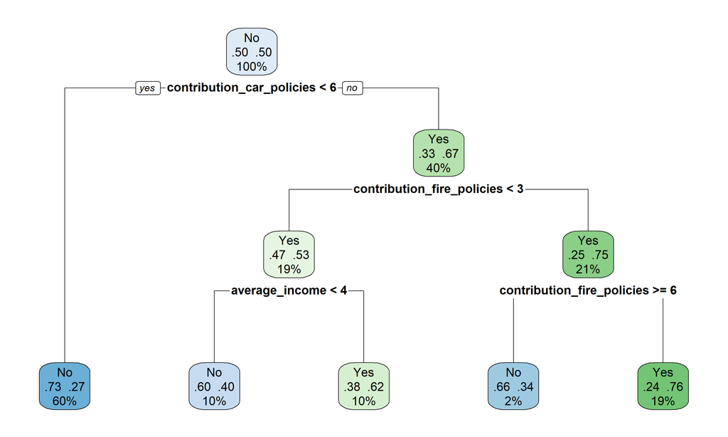

```r
rpart.plot(tree_final, type = 2, extra = 104, fallen.leaves = TRUE, varlen = 0)
```

```r
if (nrow(tree_final$frame) > 1) rpart.rules(tree_final) else cat("Tree hanya akar; belum ada aturan pembeda.")
```

```
##  Purchase
##      0.27 when contribution_car_policies <  6
##      0.34 when contribution_car_policies >= 6 & contribution_fire_policies >=      6
##      0.40 when contribution_car_policies >= 6 & contribution_fire_policies <  3      & average_income <  4
##      0.62 when contribution_car_policies >= 6 & contribution_fire_policies <  3      & average_income >= 4
##      0.76 when contribution_car_policies >= 6 & contribution_fire_policies is 3 to 6
```

**Cara baca:** mulai dari akar; ikuti kondisi cabang sampai daun. `extra = 104` menampilkan kelas, skor kedua kelas, serta persentase observasi. Skor mengikuti prior seimbang, bukan purchase rate mentah. Importance menunjukkan kontribusi terhadap pemisahan, termasuk peran split pengganti; bukan bukti sebab-akibat.

### Purchase rate asli pada daun

```r
profil_daun = train_glm %>%
  mutate(node = as.numeric(rownames(tree_final$frame)[tree_final$where])) %>%
  group_by(node) %>%
  summarise(jumlah = n(), pembeli = sum(Purchase == "Yes"),
            purchase_rate = mean(Purchase == "Yes"), .groups = "drop") %>%
  arrange(desc(purchase_rate))
profil_daun
```

```
## # A tibble: 5 × 4
##    node jumlah pembeli purchase_rate
##   <dbl>  <int>   <int>         <dbl>
## 1    15    790     132        0.167
## 2    13    391      36        0.0921
## 3    12    399      16        0.0401
## 4    14     64       2        0.0312
## 5     2   2430      57        0.0235
```

```r
aturan_top = paste(path.rpart(tree_final, nodes = profil_daun$node[1],
                             print.it = FALSE)[[1]][-1], collapse = " DAN ")
if (aturan_top == "") aturan_top = "Semua pelanggan tanpa split"
```

**Interpretasi bisnis:** Variabel dengan importance terbesar adalah contribution_car_policies . Daun dengan purchase rate training tertinggi mengikuti aturan **contribution_car_policies>=5.5 DAN contribution_fire_policies>=2.5 DAN contribution_fire_policies< 5.5**, berisi **790 pelanggan** dan **132 pembeli** (rate **16.7%**). Ini profil kandidat, bukan jaminan hasil kampanye; periksa dukungan jumlah pelanggan dan hasil test.

## (c) Validasi (4 poin)

### Evaluasi utama pada test yang sama

```r
prob_tree_train = predict(tree_final, train_glm, type = "prob")[, "Yes"]
threshold_tree = pilih_threshold(prob_tree_train, train_glm$Purchase)$threshold
prob_tree = predict(tree_final, test, type = "prob")[, "Yes"]
hasil_tree = evaluasi_model(prob_tree, test$Purchase, threshold_tree)
hasil_tree$confusion_matrix
```

```
##          Actual
## Predicted   No  Yes
##       No  1180   34
##       Yes  463   71
```

```r
round(rbind(GLM = hasil_step$metrik, Tree = hasil_tree$metrik), 3)
```

```
##        AUC Akurasi Sensitivitas Spesifisitas Presisi
## GLM  0.719   0.595        0.743        0.586   0.103
## Tree 0.707   0.716        0.676        0.718   0.133
```

### Alternatif ringkas — confusion matrix dengan caret

```r
pred_tree_lib = factor(ifelse(prob_tree >= threshold_tree, "Yes", "No"), levels = c("No", "Yes"))
cm_tree = caret::confusionMatrix(pred_tree_lib, test$Purchase, positive = "Yes", mode = "everything")
cm_tree$table
```

```
##           Reference
## Prediction   No  Yes
##        No  1180   34
##        Yes  463   71
```

```r
cm_tree$byClass[c("Sensitivity", "Specificity", "Precision")]
```

```
## Sensitivity Specificity   Precision
##   0.6761905   0.7181984   0.1329588
```

### Alternatif ringkas — ROC-AUC dengan pROC

```r
roc_tree = pROC::roc(test$Purchase, prob_tree,
                    levels = c("No", "Yes"), direction = "<", quiet = TRUE)
pROC::auc(roc_tree)
```

```
## Area under the curve: 0.7072
```

### Grafik ROC manual dan alternatif ringkas ggplot

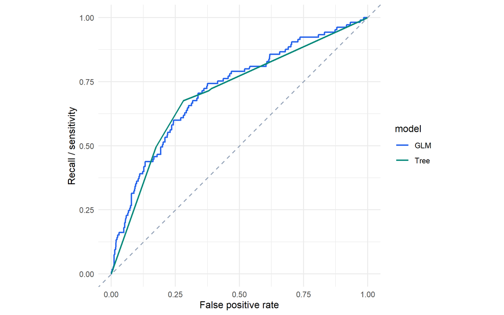

```r
# Hanya menggambar hasil evaluasi; tidak untuk memilih threshold dari test
buat_roc = function(prob, aktual, nama) {
  batas = c(Inf, sort(unique(prob), decreasing = TRUE), -Inf)
  data.frame(
    FPR = sapply(batas, function(b) mean(prob[aktual == "No"] >= b)),
    TPR = sapply(batas, function(b) mean(prob[aktual == "Yes"] >= b)),
    model = nama)
}
roc_plot = bind_rows(buat_roc(prob_step, test$Purchase, "GLM"),
                     buat_roc(prob_tree, test$Purchase, "Tree"))

ggplot(roc_plot, aes(x = FPR, y = TPR, color = model)) +
  geom_path(linewidth = 0.8) +
  geom_abline(slope = 1, intercept = 0, linetype = "dashed", color = "#94A3B8") +
  scale_color_manual(values = c(GLM = "#2563EB", Tree = "#00897B")) +
  coord_equal() + labs(x = "False positive rate", y = "Recall / sensitivity") +
  theme_minimal()
```

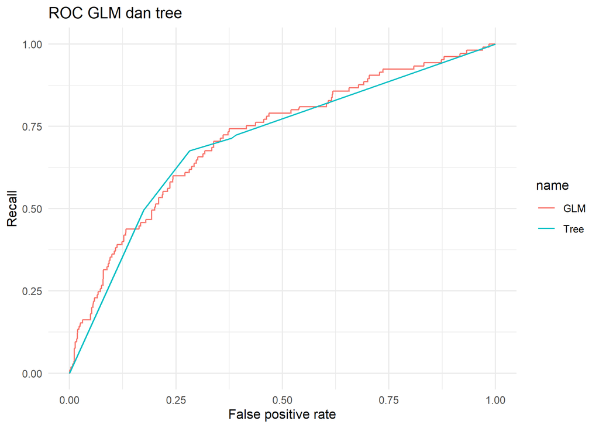

```r
pROC::ggroc(list(GLM = roc_glm, Tree = roc_tree), legacy.axes = TRUE) +
  theme_minimal() + labs(title = "ROC GLM dan tree", x = "False positive rate", y = "Recall")
```

**Interpretasi:** AUC GLM **0.719**, tree **0.707**. AUC lebih tinggi berarti ranking pembeli dan bukan pembeli lebih baik pada test ini. Kurva mendekati kiri atas lebih baik; cek angka AUC juga. Recall/specificity/precision menggunakan threshold training dan bisa berubah jika threshold diubah; AUC memakai skor. Semua alternatif di atas dijalankan langsung dan tidak menimpa hasil utama. Fungsi grafik ROC manual tersedia untuk memahami perhitungannya; untuk hafalan cukup gunakan `pROC::ggroc()` tepat di bawahnya.

## (d) Rekomendasi model (3 poin)

### 1. Perbandingan targeting top 20%

```r
top20_tree = test %>% mutate(prob = prob_tree) %>%
  arrange(desc(prob), id) %>% slice_head(n = n_kontak)
capture_tree = sum(top20_tree$Purchase == "Yes") / sum(test$Purchase == "Yes")
rate_top_tree = mean(top20_tree$Purchase == "Yes")
lift_tree = rate_top_tree / rate_test
compare_targeting = data.frame(
  model = c("GLM", "Tree"),
  AUC = c(hasil_step$metrik["AUC"], hasil_tree$metrik["AUC"]), kontak = n_kontak,
  pembeli_tercakup = c(sum(top_20_persen$Purchase == "Yes"), sum(top20_tree$Purchase == "Yes")),
  capture20 = c(capture_rate, capture_tree), rate20 = c(rate_top20, rate_top_tree),
  lift20 = c(lift, lift_tree))
compare_targeting
```

```
##   model       AUC kontak pembeli_tercakup capture20    rate20   lift20
## 1   GLM 0.7187230    349               49 0.4666667 0.1404011 2.337345
## 2  Tree 0.7072371    349               54 0.5142857 0.1547278 2.575849
```

Gunakan kuota dan test yang sama. Pada kuota sama, capture dan lift memberikan urutan model yang sama; AUC melengkapi penilaian seluruh ranking. Skor seri dipecahkan dengan ID tanpa melihat Purchase. Tree sering memberi skor sama dalam satu daun; uji sensitivitas pilihan anggota jika kuota memotong daun tersebut.

### 2. Pemeriksaan singkat kestabilan daftar

Ambil ulang 80% tiap kelas training sebanyak 5 kali, gunakan formula/cp tetap, dan hitung overlap daftar top20. Label test tidak dipakai. Kode tambahan ini menjawab aspek kestabilan pada soal, terpisah dari kode inti tree yang perlu dihafal.

```r
kontrol_ulang = kontrol_tree
kontrol_ulang$xval = 0
stabilitas = matrix(NA, 5, 2, dimnames = list(NULL, c("GLM", "Tree")))
for (i in 1:5) {
  set.seed(500 + i)
  train_sub = train_glm %>% group_by(Purchase) %>% slice_sample(prop = 0.8) %>% ungroup()
  g = glm(formula(model_step), data = train_sub, family = binomial)
  t = prune(update(tree_awal, data = train_sub, control = kontrol_ulang), cp = cp_tree)
  ig = order(-predict(g, test, type = "response"), test$id)[1:n_kontak]
  it = order(-predict(t, test, type = "prob")[, "Yes"], test$id)[1:n_kontak]
  stabilitas[i, ] = c(mean(test$id[ig] %in% top_20_persen$id),
                      mean(test$id[it] %in% top20_tree$id))
}
ringkasan_stabilitas = data.frame(model = colnames(stabilitas),
  overlap_mean = colMeans(stabilitas), overlap_min = apply(stabilitas, 2, min))
ringkasan_stabilitas
```

```
##      model overlap_mean overlap_min
## GLM    GLM    0.9495702   0.9340974
## Tree  Tree    0.9111748   0.7851003
```

Overlap 0,80 berarti 80% anggota daftar kontak tetap sama setelah perubahan sampel training. Seed hanya membuat hasil dapat diulang. Pemeriksaan ini belum mengukur kestabilan lintas waktu atau seluruh proses seleksi. Tree hanya akar bisa tampak stabil akibat urutan ID; baca bersama AUC/lift dan jumlah split.

### 3. Keputusan model berdasarkan hasil, interpretabilitas, dan risiko

```r
overlap_glm = ringkasan_stabilitas$overlap_mean[ringkasan_stabilitas$model == "GLM"]
overlap_tree = ringkasan_stabilitas$overlap_mean[ringkasan_stabilitas$model == "Tree"]
daun_tree = sum(tree_final$frame$var == "<leaf>")
selisih_pembeli = compare_targeting$pembeli_tercakup[2] - compare_targeting$pembeli_tercakup[1]

pilih_tree = selisih_pembeli > 3 && daun_tree <= 8 && overlap_tree >= 0.70
model_rekomendasi = if (pilih_tree) "Tree" else "GLM"
hasil_rekomendasi = compare_targeting %>% filter(model == model_rekomendasi)
layak_pilot = hasil_rekomendasi$lift20 > 1

compare_targeting %>%
  left_join(ringkasan_stabilitas, by = "model")
```

```
##   model       AUC kontak pembeli_tercakup capture20    rate20   lift20
## 1   GLM 0.7187230    349               49 0.4666667 0.1404011 2.337345
## 2  Tree 0.7072371    349               54 0.5142857 0.1547278 2.575849
##   overlap_mean overlap_min
## 1    0.9495702   0.9340974
## 2    0.9111748   0.7851003
```

```r
model_rekomendasi
```

```
## [1] "Tree"
```

| Pertimbangan | Bukti dan implikasi keputusan |
| --- | --- |
| Kapasitas 20% | GLM capture **46.7%**, lift **2.34**; tree capture **51.4%**, lift **2.58**. Prioritas bisnis ialah konsentrasi pembeli dalam daftar kontak. |
| AUC | GLM **0.719**, tree **0.707**. Ranking seluruh pelanggan melengkapi hasil top20. |
| Interpretabilitas | GLM memiliki **6 prediktor** dan OR untuk arah asosiasi; tree memiliki **5 daun**, dengan aturan eksplisit pada output `rpart.rules()`. Pohon yang lebih besar belum tentu lebih mudah dibaca. |
| Kestabilan | Overlap top20 rata-rata GLM **95%**, tree **91.1%**. Ini bukti perturbasi sampel terbatas, bukan jaminan periode berikutnya. |
| Risiko keputusan | Pada threshold training, GLM FP **681**, FN **27**; tree FP **463**, FN **34**. FP dapat menghabiskan biaya kontak, FN melewatkan pembeli; dampak finansial belum dapat dihitung tanpa biaya/margin. |

**Kandidat dari hasil perbandingan: Tree.** Gunakan metrik test dan pemeriksaan kestabilan di tabel; rekomendasi masih memerlukan validasi baru/pilot.

**Rekomendasi sementara:** **Tree**. Selisih pembeli tercakup tree−GLM adalah **5 pelanggan** pada kuota yang sama (negatif berarti lebih sedikit). Tree memiliki **5 daun** dan overlap **91.1%**. Tree memenuhi ketiga kriteria praktis yang dinyatakan sebelum perbandingan, sehingga menjadi kandidat pilot.

Lift kandidat di atas 1 mendukung pengujian daftar prioritas melalui pilot terkontrol, belum peluncuran penuh.

Jika GLM undersampling pada Tugas 4 tampak lebih baik, jadikan kandidat tambahan untuk validasi berikutnya. Jangan berulang kali mengganti model untuk mengejar satu hasil test. Setelah test dipakai merekomendasikan model, diperlukan holdout baru atau pilot agar penilaian lanjutan tidak terlalu optimistis.

**Risiko top20 berbeda dari confusion matrix:** confusion matrix di atas memakai threshold training dan bisa menghasilkan jumlah prediksi Yes yang tidak sama dengan kuota. Pada daftar 20%, pelanggan terhubung yang tidak membeli = `n_kontak − pembeli_tercakup`, sedangkan pembeli terlewat = seluruh pembeli test − pembeli_tercakup. Ini risiko yang lebih langsung sesuai kapasitas pemasaran. Historical Purchase tetap belum menunjukkan pembelian tambahan akibat kontak pemasaran.

# Tugas 6 (15 poin): Executive Recommendation

| Subnomor | Penjelasan | Solusi | Fungsi Utama |
| --- | --- | --- | --- |
| 1 | Anda diminta menjelaskan masalah bisnis kepada manajemen. | 1. Nyatakan biaya kontak dan kuota 20%. 2. Hubungkan analisis dengan prioritas pelanggan, bukan sekadar accuracy. | `n_kontak`, `nrow(test)` |
| 2 | Anda diminta menjelaskan kualitas dan keterbatasan data. | 1. Laporkan missing/duplikasi terpilih. 2. Jelaskan profil wilayah, kode kategori, fokus 14 prediktor, dan keterbatasan validasi historis. | `sum(is.na())`, `duplicated()`, `rate_all` |
| 3 | Anda diminta memberikan 3–5 insight EDA/segmentasi. | 1. Ambil empat temuan dari ranking, polis mobil, segmentasi daya beli, dan cluster. 2. Sertakan jumlah/rate agar klaim dapat diperiksa. 3. Hindari klaim sebab-akibat. | `ranking`, `rate_mobil`, `segmen`, `ringkasan_cluster` |
| 4 | Anda diminta merekomendasikan model. | 1. Gunakan hasil Tugas 5. 2. Nyatakan sebagai kandidat pilot, bukan jaminan produksi. Alternatif: lanjut validasi jika belum ada lift. | `model_rekomendasi`, `hasil_rekomendasi` |
| 5 | Anda diminta menentukan ukuran performa relevan. | 1. Utamakan capture/lift top20 dan rate daftar. 2. Lengkapi dengan AUC serta biaya/risiko. Jangan menyamakan lift dengan kenaikan penjualan kausal. | `capture20`, `lift20`, `rate20`, `AUC` |
| 6 | Anda diminta rekomendasi implementasi. | 1. Pilot terkontrol dengan kelompok acak pembanding. 2. Pantau hasil, biaya, keluhan, dan perubahan populasi. 3. Validasi baru/kalibrasi sebelum scale-up. | Daftar ranking; monitoring dan rancangan pilot |
| 7 | Anda diminta menyebut data tambahan. | 1. Kumpulkan ID/waktu, biaya kontak, margin, respons kampanye, dan kebutuhan caravan. 2. Jelaskan manfaatnya untuk deduplikasi, validasi waktu, serta hasil tambahan kampanye. | Data tambahan untuk evaluasi bisnis berikutnya |

## Ringkasan manajemen maksimal 400 kata

Ringkasan berikut **dihasilkan dari objek analisis yang sudah dihitung**, sehingga angka mengikuti output Knit. Empat insight deskriptif bukan hasil kausal. Jika model gagal konvergen atau hasil audit memerlukan perubahan, selesaikan masalah tersebut sebelum memakai ringkasan. Kesimpulan tidak boleh lebih kuat daripada bukti yang tersedia.

Perusahaan perlu mengurangi kontak pemasaran yang kurang produktif dan memprioritaskan pelanggan karena kapasitas hanya 20%. Tujuannya menemukan daftar calon pembeli yang lebih terkonsentrasi dengan biaya terkendali.

Analisis memakai 14 prediktor dan 5822 pelanggan. Purchase rate historis 5.98%. Ditemukan 0 nilai hilang dan 1307 baris tambahan identik pada kolom pilihan. Baris identik dipertahankan tanpa bukti pencatatan ganda. Profil wilayah dan kode kategori tidak selalu menggambarkan kondisi individu.

Empat temuan: (1) kode kontribusi polis mobil menunjukkan perbedaan relatif terbesar antara pembeli dan bukan pembeli; (2) pelanggan dengan polis mobil memiliki rate 9.27%, dibanding 2.53% tanpa polis; (3) kelas daya beli 7 memiliki rate 14.14% pada 474 pelanggan; (4) cluster 2 memiliki rate 11.48% pada 1838 pelanggan. Segmentasi ini membantu merancang pesan, belum membuktikan penyebab pembelian.

Pohon keputusan direkomendasikan sebagai kandidat pilot, berdasarkan hasil kontak terbatas, kemudahan penjelasan, dan pemeriksaan kestabilan; belum untuk peluncuran penuh.

Pada test yang sama, daftar 349 kontak model tersebut mencakup 51.4% seluruh pembeli aktual, dengan purchase rate 15.47% dan konsentrasi 2.58 kali rata-rata test. Ukuran ini lebih relevan daripada persentase label benar; skor kemampuan membedakan pembeli adalah 0.707 (0,5 setara acak; 1 sempurna). Hasil satu split dan perturbasi sampel terbatas belum menjamin kinerja periode berikutnya.

Uji daftar prioritas melalui pilot dengan kelompok pembanding acak. Pantau pembelian tambahan, biaya per pembeli, margin, dan keluhan; validasi pada periode baru serta periksa kalibrasi sebelum memperluas kampanye. Konsentrasi pembeli historis belum sama dengan dampak tambahan pemasaran.

Kumpulkan ID pelanggan, tanggal pengamatan, riwayat/respons kontak, biaya kontak, margin polis, serta kebutuhan atau kepemilikan caravan. Data tersebut membantu audit pelanggan, validasi waktu, pemahaman kebutuhan, dan pengukuran keuntungan tambahan kampanye.

**Jumlah kata ringkasan:** 264 kata. Pemandu dan tabel di luar ringkasan bukan bagian dari jawaban 400 kata.

## Strategi menulis ulang saat ujian

Tuliskan ringkasan setelah semua hasil tersedia. Susun urutan **masalah bisnis → kualitas/batas data → 3–5 temuan → model → hasil top20 → pilot → data tambahan**. Ganti nama kolom pada naskah manajemen dengan makna bisnis dari kamus, bukan menyalin seluruh output teknis. Kalimat “layak diprioritaskan untuk uji penawaran” lebih sesuai bukti deskriptif daripada “pasti membeli” atau “kampanye meningkatkan penjualan sebesar lift”. Jika suatu klaim tidak memiliki angka/tabel pendukung, hapus atau nyatakan sebagai usulan pengujian.

# Lampiran A: Lembar Hafalan

Gunakan tabel ini untuk mengingat **alur, fungsi, dan interpretasi**, bukan menyalin hasil angka. Nama objek mengikuti kode utama agar mudah dicari kembali.

| Materi | Syntax/pola utama | Hal yang harus diingat |
| --- | --- | --- |
| Pilih dan rename | `select()` → `rename()` | Tetapkan prediktor sejak awal; nama Inggris tidak mengubah skala. |
| Missing value | `sum(is.na(dat))`; `colSums(is.na(dat))` | Cek total dan per kolom; tidak perlu imputasi jika tidak ada missing. |
| Baris identik | `sum(duplicated(dat))` | Kesamaan profil belum membuktikan pencatatan ganda. |
| Variasi | `sapply(dat, n_distinct)`; `table()` | Keluarkan konstan; dominasi ≥95% ialah aturan audit sederhana, bukan aturan universal. |
| Tipe data | `str()`; `factor(..., levels=c("No","Yes"))` | Kode nominal bukan ukuran numerik; Yes adalah kelas positif. |
| Ketimpangan kelas | `table()`; `prop.table()` | Accuracy dapat tinggi hanya karena No dominan. |
| Cleaning | `na.omit()`; `unique()` (jika terbukti perlu) | Pilih solusi berdasarkan masalah, jangan membuang data secara otomatis. |
| Statistik per kelas | `psych::describeBy(X, group=dat$Purchase)` | Pilih mean, median, SD, skew; jangan mencetak semua statistik tanpa tujuan. |
| Pembeda relatif | selisih mean ÷ akar rata-rata varians kedua kelas | Nilai absolut besar berarti beda relatif besar; bukan uji kausal/signifikansi. |
| Bar plot rate | `group_by()` → `summarise()` → `geom_col()` | Rate memakai pembagi jumlah pelanggan pada kelompok. |
| Boxplot | `ggplot(dat, aes(Purchase, variabel)) + geom_boxplot()` | Bandingkan median/IQR; outlier tidak otomatis salah. |
| Histogram | `geom_histogram(aes(y=after_stat(density)))` | Density membandingkan bentuk distribusi meski kelas tidak seimbang. |
| Scatter/jitter | `geom_point()` atau `geom_jitter()` | Jitter membantu melihat tumpang tindih, bukan mengubah data asli. |
| Bar proporsi | `geom_bar(position="fill")` | Proporsi seluruh bagian batang =1; periksa kelas/kelompok pembaginya. |
| Heatmap | `geom_tile()` + `geom_text()` | Warna dan angka menunjukkan ukuran yang disebut pada legenda. |
| ECDF | `stat_ecdf(geom="step")` | y = proporsi dengan nilai ≤x; cocok untuk kode diskrit. |
| Segmentasi bisnis | `group_by(satu_variabel)` → `mean(Purchase=="Yes")` | Jelaskan rate + jumlah pelanggan/pembeli + baseline. |
| Input PCA | `select(where(is.numeric))` setelah audit | Keluarkan target, ID, nominal, dan konstan; jelaskan asumsi kode ordinal. |
| Standardisasi PCA | `prcomp(dat_pca, scale.=TRUE)` | Perbedaan skala/variansi tidak boleh mendominasi analisis. |
| PC minimal 70% | `get_eigenvalue()` → `which(eigenvalue$cumulative.variance.percent>=70)[1]` | Gunakan PC pertama sampai ambang benar-benar tercapai. |
| Loading | `pca$rotation`; `which.max(abs(...))` | Besar kontribusi dan arah; bukan OR/efek kausal. |
| Skor PCA | `pca$x[, 1:jumlah_pc, drop=FALSE]` | Skor adalah input K-means; rotation adalah loading, bukan skor pelanggan. |
| Grafik cluster | `fviz_cluster(km, data=skor_pc, choose.vars=c("PC1","PC2"), stand=FALSE)` | Dua sumbu asli; tidak melakukan scaling/PCA ulang. |
| K-means | `fviz_nbclust()` → `kmeans(skor_pc, centers=best_k, nstart=25)` | Bandingkan k=2,…,6; fit ulang k terpilih, bukan memakai hasil loop terakhir. |
| Kualitas cluster | `fviz_nbclust(method="wss")`; `method="silhouette"` | Pilih k tanpa Purchase; WSS turun saat k meningkat. |
| Purchase per cluster | `prop.table(tabel_cluster, 1)` | Baca Purchase setelah cluster terbentuk; beri insight rate + ukuran + profil. |
| Split stratified | `group_by(Purchase)` → `slice_sample(prop=.7)` → `anti_join()` | Sekitar 70% tiap kelas; test asli dan tidak beririsan. |
| Kandidat model | `select(-id, -customer_subtype, -rented_house, -number_of_car_policies)` | ID/cluster bukan prediktor; keputusan model tidak memakai label test. |
| GLM | `glm(..., family=binomial)` | Target biner; efek numerik linear pada log-odds adalah asumsi. |
| Seleksi GLM | `step(..., direction="both")` | Seleksi pada training; AIC dibandingkan pada data fit yang sama. |
| Odds ratio | `exp(coef(model_step))` | Perubahan odds per unit, prediktor lain tetap; bukan perubahan probabilitas. |
| Skor GLM | `predict(..., type="response")` | Probabilitas Yes; model seimbang dapat perlu kalibrasi populasi. |
| Undersampling | `filter()` → `slice_sample()` → `bind_rows()` | Hanya training; tidak selalu lebih baik dan membuang sebagian No. |
| Threshold | `pilih_threshold(prob_train, train$Purchase)` | Pilih dari training/validation, jangan dari test. |
| Confusion matrix | `table(Predicted, Actual)` | Baris prediksi, kolom aktual; TP/FP/FN/TN harus konsisten. |
| ROC-AUC | `evaluasi_model(... )$metrik["AUC"]` | Kualitas ranking seluruh pelanggan, tidak tergantung threshold. |
| Recall | `TP/(TP+FN)` | Dari seluruh pembeli, berapa yang terdeteksi. |
| Specificity | `TN/(TN+FP)` | Dari bukan pembeli, berapa yang diprediksi No. |
| Precision | `TP/(TP+FP)` | Dari prediksi Yes, berapa yang aktual Yes; NA jika tidak ada prediksi Yes. |
| Decision tree | `rpart(..., method="class", parms=list(prior=c(.5,.5)))` | Prior seimbang memberi perhatian kedua kelas; tidak mengkalibrasi skor populasi. |
| Pruning CV | `tree_awal$cptable` → `prune(..., cp=cp_tree)` | Pilih cp dari CV training; xerror bukan AUC/lift. |
| Tree berwarna | `rpart.plot(..., type=2, extra=104, fallen.leaves=TRUE)` | Kotak memuat kelas, skor No/Yes, dan proporsi observasi node. |
| Importance/aturan | `variable.importance`; `rpart.rules()` | Jelaskan aturan aktual dan dukungan daun, bukan kausalitas. |
| Skor tree | `predict(..., type="prob")[,"Yes"]` | Untuk ranking/AUC, gunakan skor, bukan label kelas. |
| Kestabilan | overlap top20 setelah perubahan sampel training | Seed membuat bisa diulang; overlap memberi diagnostik, bukan jaminan masa depan. |
| Top20 | `arrange(desc(prob), id)` → `slice_head(n=n_kontak)` | Kuota berbeda dari threshold; aturan seri tidak memakai Purchase. |
| Capture | pembeli top20 ÷ seluruh pembeli test | Persentase pembeli yang berada dalam kapasitas kontak. |
| Lift | rate top20 ÷ rate seluruh test | Konsentrasi pembeli terhadap baseline; bukan kenaikan penjualan kausal. |
| Pilih model | tabel AUC + top20 + stabilitas + interpretabilitas | Periksa risiko FP/FN dan kebutuhan validasi baru setelah pemilihan. |
| Rekomendasi manajemen | masalah → bukti → model → pilot → data tambahan | Maksimal 400 kata; jangan menulis klaim lebih kuat dari hasil. |

# Lampiran B: Checklist akhir Tugas 1–6

- Tugas 1: lima aspek audit, masalah/bukti/akibat/tindakan, keputusan duplikasi, dan persiapan tiga metode.
- Tugas 2(a): jumlah/persen Purchase, pembeda relatif, dan alasan mean saja tidak cukup.
- Tugas 2(b): untuk ujian pilih maksimal tiga grafik; tiap grafik punya pertanyaan, alasan, interpretasi, dan batas.
- Tugas 2(c): satu variabel segmentasi, jumlah pelanggan/pembeli, purchase rate, dan rekomendasi beralasan.
- Tugas 3(a): input numerik tanpa target, standardisasi, PC ≥70%, loading PC1/PC2, dan keterbatasan.
- Tugas 3(b): k=2–6, kualitas, k terpilih, Purchase setelah clustering, dan insight bisnis.
- Tugas 4(a)–(b): split stratified, fit/seleksi pada training, diagnostik, serta dua OR bisnis.
- Tugas 4(c)–(d): threshold training, metrik lengkap, top20, capture/lift, dan relevansi bisnis.
- Tugas 5: perhatian pada imbalance, pruning CV, importance/aturan, AUC test, dan rekomendasi berbukti.
- Tugas 6: ≤400 kata, tujuh unsur soal terjawab, angka sesuai output, tanpa klaim kausal.

# Lampiran C: Alur Rekomendasi dan Debugging

## Tabel alur pengerjaan yang direkomendasikan

| Urutan | Apa yang dilakukan | Hasil yang disimpan | Keputusan sebelum lanjut |
| --- | --- | --- | --- |
| 1. Baca soal/data | Tetapkan target positif, kapasitas pemasaran, prediktor, dan kamus skala. Pilih kolom lalu rename. | `dat_asli` | Apakah nama/makna kolom benar dan seluruh unsur soal teridentifikasi? |
| 2. Audit | Periksa missing, profil identik, variasi, tipe, dan kelas Purchase. | `audit_var`, tabel kualitas | Masalah nyata apa yang perlu ditangani? Jangan memilih cleaning otomatis. |
| 3. Cleaning/persiapan | Pertahankan profil identik tanpa bukti salah; keluarkan konstan; perbaiki nominal/target. | `dat_clean` → `dat` | Jika ada missing pada data lain, tentukan strategi yang sesuai; imputasi prediktif dipelajari dari training. |
| 4. Ringkasan dan grafik | Ringkas per kelas, urutkan pembeda, baca distribusi. Jelajahi semua grafik latihan. | `ranking`, tabel rate, grafik | Pilih tiga grafik final yang menjawab pertanyaan berbeda dan cek pembaginya. |
| 5. Segmentasi bisnis | Kelompokkan satu variabel, hitung jumlah/pembeli/rate dan baseline. | `segmen` | Apakah dukungan data cukup dan indikator layak untuk pilot, tanpa klaim kausal? |
| 6. PCA | Input numerik lolos audit, standardisasi, pilih PC ≥70%, baca loading. | `dat_pca`, `pca`, `jumlah_pc` | Jangan masukkan target; jangan memakai loading sebagai skor pelanggan. |
| 7. Clustering | Bandingkan k=2–6, kualitas, dan ukuran; fit ulang k terpilih. Baca Purchase setelah fit. | `km`, `ringkasan_cluster` | Jelaskan rate + ukuran + profil; kualitas rendah harus dilaporkan. |
| 8. Split prediktif | Split stratified 70:30; jangan menyeimbangkan test. Kandidat model ditetapkan tanpa ranking test. | `train`, `test` | Cek kelas dan ID tidak beririsan. Pada proyek nyata, sisihkan holdout lebih awal. |
| 9. GLM | Fit/seleksi pada training; cek konvergensi dan OR; pilih threshold training. | `model_step`, `threshold` | Apakah koefisien/diagnostik masuk akal dan tidak ada pemilihan dari label test? |
| 10. Tree | Fit pada training yang sama; atur imbalance; prune dari CV, baca aturan. | `tree_final`, `cp_tree` | Gunakan cp CV, bukan memilih tree dari performa test. |
| 11. Evaluasi bisnis | Nilai test, AUC/matriks, top20, capture/lift, overlap daftar, dan aturan. | `compare_targeting`, `ringkasan_stabilitas` | Pilih kandidat secara terbuka; sesudah test dipakai memilih model, konfirmasi pada data baru. |
| 12. Rekomendasi | Ringkas masalah, kualitas, 3–5 insight, model, ukuran bisnis, pilot, data tambahan. | `executive` | Semua klaim punya angka/tabel pendukung dan ringkasan ≤400 kata. |

**Saat berganti dataset:** pertahankan urutan, ulangi audit, dan sesuaikan nama target/kelas positif, makna prediktor, ambang PC, jumlah cluster, ukuran daun, serta kapasitas kontak. Jangan menyalin angka Caravan. Target multikelas atau numerik membutuhkan model/metrik berbeda dari GLM binomial ini.

## Tabel debugging singkat

Baca **error pertama**, cari chunk tempat error muncul, lalu perbaiki penyebabnya. Jangan menjalankan potongan hilir ketika objek hulunya belum terbentuk. Sesudah perbaikan, Knit dari awal untuk memastikan seluruh alur bekerja.

[output not shown]

**Prinsip debugging:** perbaiki masalah datanya/urutannya lebih dahulu, kemudian paket/parameter yang relevan. `warning=FALSE` atau `error=TRUE` bukan pengganti perbaikan penyebab error.

# Lampiran D: Rujukan Fungsi Utama

- [psych: describeBy](https://www.personality-project.org/r/psych/help/describe.by.html)
- [ggplot2: histogram](https://ggplot2.tidyverse.org/reference/geom_histogram.html) dan [ECDF](https://ggplot2.tidyverse.org/reference/stat_ecdf.html)
- [factoextra: eigenvalue](https://rpkgs.datanovia.com/factoextra/reference/eigenvalue.html), [jumlah cluster](https://rpkgs.datanovia.com/factoextra/reference/fviz_nbclust.html), dan [grafik cluster](https://rpkgs.datanovia.com/factoextra/reference/fviz_cluster.html)
- [R: prcomp](https://stat.ethz.ch/R-manual/R-devel/library/stats/html/prcomp.html), [silhouette](https://stat.ethz.ch/R-manual/R-devel/library/cluster/html/silhouette.html), dan [step](https://stat.ethz.ch/R-manual/R-devel/library/stats/html/step.html)
- [R: rpart](https://stat.ethz.ch/R-manual/R-devel/library/rpart/html/rpart.html), [rpart.control](https://stat.ethz.ch/R-manual/R-devel/library/rpart/html/rpart.control.html), dan [prune](https://stat.ethz.ch/R-manual/R-devel/library/rpart/html/prune.rpart.html)
- [R: path.rpart](https://stat.ethz.ch/R-manual/R-devel/library/rpart/html/path.rpart.html) dan [predict.rpart](https://stat.ethz.ch/R-manual/R-devel/library/rpart/html/predict.rpart.html)
- [rpart.plot: visualisasi node](https://stat.ethz.ch/CRAN/web/packages/rpart.plot/refman/rpart.plot.html)
- [R: namespace dan pemeriksaan versi](https://stat.ethz.ch/R-manual/R-devel/library/base/html/ns-load.html)
- [caret: confusionMatrix](https://search.r-project.org/CRAN/refmans/caret/html/confusionMatrix.html)
- [pROC: roc](https://search.r-project.org/CRAN/refmans/pROC/html/roc.html), [coords](https://search.r-project.org/CRAN/refmans/pROC/html/coords.html), dan [ggroc](https://search.r-project.org/CRAN/refmans/pROC/html/ggroc.html)
- [rpart.plot: rpart.rules](https://search.r-project.org/CRAN/refmans/rpart.plot/html/rpart.rules.html)

# Lampiran E: Semangat dan Latihan Lanjutan

**Semangat belajar dan mempersiapkan ujian!** Tidak harus langsung hafal semuanya. Kuncinya sering latihan: tulis ulang kode, baca output, dan jelaskan hasil dengan kata-kata sendiri. Jangan lupa berdoa sebelum belajar dan sebelum ujian; imbangi ikhtiar dengan istirahat yang cukup. Satu kesalahan yang dipahami hari ini bisa menjadi bekal agar tidak terulang saat ujian.

## Cara berlatih agar alurnya melekat

| Putaran latihan | Fokus | Tanda sudah paham |
| --- | --- | --- |
| 1. Dengan panduan | Jalankan dari awal, baca tiap output, cocokkan dengan soal. | Bisa menjelaskan setiap objek dibuat untuk menjawab bagian apa. |
| 2. Tanpa menyalin | Tulis kembali pola fungsi dari Lembar Hafalan; buat tiga grafik pilihan sendiri. | Bisa membedakan pembagi rate/recall/precision dan menjelaskan grafik. |
| 3. Dataset berbeda | Ulangi audit, preprocessing, split, model, dan metrik sesuai target baru. | Tidak bergantung pada nama kolom/angka Caravan. |
| 4. Simulasi ujian | Kerjakan dengan batas waktu, tulis interpretasi dan ringkasan manajemen. | Jawaban lengkap, ringkas, angka sesuai output, tidak ada kebocoran test. |

Sesudah tiap latihan, catat satu error, penyebabnya, dan perbaikannya. Latih interpretasi sesering kode: **hasil apa → arti apa → keputusan apa → batasnya apa**.

## Dataset dari paket R untuk alur serupa

Pilihan berikut telah dicek dari dokumentasi paket R. Gunakan sebagai **kasus latihan terpisah**, bukan menambahkan observasi ke Caravan. Semua mempunyai target biner yang dapat dipetakan ke No/Yes; arti top20 harus disesuaikan dengan tujuan kasus.

| Dataset/paket | Target dan konteks | Materi yang dapat dilatih | Penyesuaian penting |
| --- | --- | --- | --- |
| **Default — ISLR2** ([dokumentasi](https://search.r-project.org/CRAN/refmans/ISLR2/html/Default.html)) | `default`: No/Yes; data simulasi 10.000 pelanggan kartu kredit. | Audit, imbalance, EDA, GLM/OR, tree, serta ranking risiko. | PCA hanya pada `balance`/`income`; `student` nominal. Top20 berarti prioritas risiko/intervensi, bukan calon pembeli. |
| **OJ — ISLR2** ([dokumentasi](https://search.r-project.org/CRAN/refmans/ISLR2/html/OJ.html)) | `Purchase`: CH/MM; 1.070 pembelian dua merek jus. | Segmentasi bisnis, harga/loyalitas, PCA/K-means, GLM/tree dan interpretasi. | Tentukan merek positif, misalnya MM. Hindari memasukkan harga dan semua turunannya sekaligus; perhatikan pengamatan toko/waktu bila melakukan validasi lebih realistis. |
| **Pima.tr2 — MASS** ([dokumentasi](https://stat.ethz.ch/R-manual/R-devel/library/MASS/html/Pima.tr.html)) | `type`: No/Yes; 300 subjek, termasuk pengamatan dengan missing prediktor. | Audit missing, imputasi training, PCA numerik, GLM/tree, serta sensitivitas/precision. | Tidak bisa menyalin strategi “tidak ada missing” Caravan. Pilih penanganan dan estimasi imputasi dari training; split harus cocok untuk sampel lebih kecil. |
| **kyphosis — rpart** ([dokumentasi](https://stat.ethz.ch/R-manual/R-devel/library/rpart/html/kyphosis.html)) | `Kyphosis`: absent/present; 81 observasi dengan tiga prediktor numerik. | Latihan tree singkat, gambar aturan, pruning, serta batas evaluasi sampel kecil. | Petakan present sebagai Yes. `minbucket=50` dari Caravan tidak cocok; ukuran daun/CV ditentukan ulang di training. Konteks interpretasinya berbeda dari targeting pemasaran. |

**Urutan latihan yang disarankan:** Default untuk membangun alur prediksi sederhana → OJ untuk memperluas EDA/segmentasi bisnis → Pima.tr2 untuk missing/imputasi → kyphosis untuk memahami aturan tree pada data kecil. Setiap kasus memerlukan interpretasi baru; clustering atau kuota top20 tidak selalu merupakan tujuan bisnis aslinya.

## Contoh pemuatan dataset latihan

Kode berikut sengaja **tidak dijalankan dalam alur Caravan**. Pilih satu kasus untuk file latihan baru. Gunakan objek berbeda agar tidak menimpa `dat`, `train`, atau `test` dari jawaban utama. ISLR2 dan rpart sudah dipakai pada panduan; MASS hanya diperlukan untuk Pima.tr2.

```r
data("Default", package = "ISLR2")
dat_latihan_default = Default %>% rename(Purchase = default)
table(dat_latihan_default$Purchase)
```

```r
data("OJ", package = "ISLR2")
dat_latihan_oj = OJ %>%
  select(Purchase, LoyalCH, PriceCH, PriceMM, DiscCH, DiscMM) %>%
  mutate(Purchase = factor(ifelse(Purchase == "MM", "Yes", "No"),
                           levels = c("No", "Yes")))
table(dat_latihan_oj$Purchase)
```

```r
# Jika MASS belum tersedia: install.packages("MASS") di Console
data("Pima.tr2", package = "MASS")
dat_latihan_pima = Pima.tr2 %>% rename(Purchase = type)
colSums(is.na(dat_latihan_pima))
```

```r
data("kyphosis", package = "rpart")
dat_latihan_tree = kyphosis %>% rename(Purchase = Kyphosis) %>%
  mutate(Purchase = factor(ifelse(Purchase == "present", "Yes", "No"),
                           levels = c("No", "Yes")))
table(dat_latihan_tree$Purchase)
```

**Target akhir latihan:** mampu memilih metode yang sesuai, menjalankan alur yang benar, dan menjelaskan keputusan dari bukti. Pelan-pelan, konsisten, dan sering berlatih. Semoga proses belajarnya lancar dan dimudahkan saat ujian!